# CLIP V3 Forensic Experiment Audit

This notebook audits the `cv_beam_v3` experiment artifacts at summary level and run level. The goal is to explain what the artifacts actually show, how stable the conclusions are, and which claims are strongly versus weakly supported by the evidence.

The notebook is intentionally forensic but reader-oriented:

- it opens real run folders, not only top-level summaries
- it includes integrity checks and explicit spot-checks against raw files
- it now teaches the experiment first, then audits it, so a newcomer can follow the later technical sections
- every major section ends with a short written finding tied to the evidence shown immediately above

```python
import json
import math
import os
import random
import re
import warnings
from pathlib import Path

import matplotlib.pyplot as plt
import numpy as np
import pandas as pd
import torch
from IPython.display import Markdown, display
from matplotlib.lines import Line2D
from sklearn.decomposition import PCA
from sklearn.manifold import TSNE
from sklearn.metrics import silhouette_score
from sklearn.neighbors import NearestNeighbors

from models.clip.fusion_heads import FusionClassifier
from models.clip.labels import REDUCED_CLASSES
from models.clip.metrics import (
    compute_flat9_metrics,
    compute_multiclass_metrics_from_predictions,
    compute_reliability_metrics,
    compute_safety_metrics_from_predictions,
)

os.environ.setdefault("LOKY_MAX_CPU_COUNT", "4")
warnings.filterwarnings("ignore", category=FutureWarning)
warnings.filterwarnings("ignore", message="Could not find the number of physical cores*")
warnings.filterwarnings("ignore", message="There are no physical cores found*")
plt.style.use("seaborn-v0_8-whitegrid")
plt.rcParams.update(
    {
        "figure.dpi": 125,
        "savefig.dpi": 150,
        "axes.titlesize": 13,
        "axes.titleweight": "semibold",
        "axes.labelsize": 11,
        "xtick.labelsize": 10,
        "ytick.labelsize": 10,
        "legend.fontsize": 9,
        "legend.frameon": True,
        "legend.framealpha": 0.92,
        "grid.alpha": 0.28,
        "axes.spines.top": False,
        "axes.spines.right": False,
    }
)
pd.set_option("display.max_columns", 120)
pd.set_option("display.max_colwidth", 240)

SEED = 42
random.seed(SEED)
np.random.seed(SEED)
torch.manual_seed(SEED)
RNG = np.random.default_rng(SEED)

CONFIG = {
    "plan_tag": "cv_beam_v3",
    "artifact_root": "output/clip"
}
STAGE_TITLES = {
    "s1_arch": "Stage 1: Architecture Warm Start",
    "s2_om": "Stage 2: Output Mode",
    "s3_ls": "Stage 3: Loss Function",
    "s4_cw": "Stage 4: Class Weighting",
    "s5_sp": "Stage 5: Sampler",
    "s6_bt": "Stage 6: Effective-Number Beta",
    "s7_pd": "Stage 7: Projection Dimension",
    "s8_aux": "Stage 8: Auxiliary / Hierarchy Weighting",
    "s9_bb2": "Stage 9: Backbone Recheck",
    "s10_opt": "Stage 10: Optimizer Sweep",
    "s11_rob": "Stage 11: Robustness Rerun"
}
STAGE_HYPOTHESES = {
    "s1_arch": "Which backbone, fusion, and head family gives the strongest starter frontier under the common training recipe?",
    "s2_om": "Does the output formulation itself matter once the backbone and head are held fixed as much as possible?",
    "s3_ls": "Does focal loss improve minority handling beyond the current CE baseline, or does it over-focus on hard examples?",
    "s4_cw": "How much of the imbalance problem is better handled by class weighting, and which weighting scheme generalizes best?",
    "s5_sp": "Do balanced samplers improve minority behavior, or do they introduce enough batch-distribution shift to hurt macro-F1?",
    "s6_bt": "If effective-number weighting survives, which beta gives the best balance between minority emphasis and stability?",
    "s7_pd": "How much fused-representation capacity is actually helpful before variance and overfitting dominate?",
    "s8_aux": "For hierarchy-aware variants, do auxiliary or unsafe-specific losses add signal or mostly add complexity?",
    "s9_bb2": "After most design choices are fixed, does a late backbone recheck materially change the strongest recipe family?",
    "s10_opt": "Within the late frontier, do optimizer settings materially separate candidates or mostly create light-budget pseudo-separation?",
    "s11_rob": "When the seed budget is broadened, which finalists remain convincing and which lose their apparent advantage?"
}
STAGE_TESTED_FIELDS = {
    "s1_arch": [
        "model_name",
        "pretrained",
        "fusion",
        "head_type"
    ],
    "s2_om": [
        "output_mode"
    ],
    "s3_ls": [
        "loss_type",
        "focal_gamma"
    ],
    "s4_cw": [
        "class_weighting"
    ],
    "s5_sp": [
        "sampler"
    ],
    "s6_bt": [
        "beta"
    ],
    "s7_pd": [
        "proj_dim"
    ],
    "s8_aux": [
        "output_mode",
        "lambda_unsafe",
        "aux_bin_w",
        "aux_unsafe_w"
    ],
    "s9_bb2": [
        "model_name",
        "pretrained"
    ],
    "s10_opt": [
        "lr",
        "weight_decay"
    ],
    "s11_rob": [
        "lr",
        "weight_decay",
        "proj_dim",
        "aux_bin_w",
        "aux_unsafe_w"
    ]
}

ROOT = Path(".").resolve()
PLAN_TAG = CONFIG["plan_tag"]
ARTIFACT_ROOT = ROOT / CONFIG["artifact_root"]
ANALYSIS_ROOT = ARTIFACT_ROOT / "analysis" / "cv3" / PLAN_TAG
STAGE_DIR = ANALYSIS_ROOT / "stg"
RUNS_ROOT = ARTIFACT_ROOT / "runs"
CALIB_ROOT = ARTIFACT_ROOT / "calibration" / "cv3" / PLAN_TAG
CACHES_ROOT = ARTIFACT_ROOT / "caches"
EXTRA_AUDIT_ROOT = ANALYSIS_ROOT / "finalist_extra_audit"

def load_json(path):
    path = Path(path)
    with path.open("r", encoding="utf-8") as fh:
        return json.load(fh)

def safe_token(value):
    return str(value).replace("/", "-").replace("\\", "-").replace(":", "-").replace(" ", "_")

def _float_token(value):
    token = f"{float(value):.6g}"
    return token.replace("-", "m").replace(".", "p")

def model_short(model_name):
    return {"ViT-B-16": "B16", "ViT-L-14": "L14"}.get(model_name, safe_token(model_name))

def pretrained_short(pretrained):
    return {
        "laion2b_s34b_b88k": "b88",
        "laion2b_s32b_b82k": "b82",
        "datacomp_xl_s13b_b90k": "dcx",
    }.get(pretrained, safe_token(pretrained))

def fusion_short(value):
    return {"concat": "c", "interaction": "it", "interaction_only": "io"}.get(value, safe_token(value))

def head_short(value):
    return {"linear": "ln", "small": "sm", "medium": "md"}.get(value, safe_token(value))

def output_mode_short(value):
    return {"flat": "fl", "hierarchical": "hi", "flat_aux_hier": "fah"}.get(value, safe_token(value))

def loss_short(value):
    return {"ce": "ce", "focal": "fc"}.get(value, safe_token(value))
```

```python
def weighting_short(value):
    return {"none": "n", "inverse": "iv", "effective": "ef"}.get(value, safe_token(value))

def sampler_short(value):
    return {"shuffle": "sh", "balanced_flat9": "bf9", "balanced_binary": "bbn"}.get(value, safe_token(value))

def spec_signature_from_cfg(cfg):
    parts = [
        f"bb-{model_short(cfg['model_name'])}{pretrained_short(cfg['pretrained'])}",
        f"fu-{fusion_short(cfg['fusion'])}",
        f"hd-{head_short(cfg['head_type'])}",
        f"om-{output_mode_short(cfg['output_mode'])}",
        f"pd-{int(cfg['proj_dim'])}",
        f"ls-{loss_short(cfg['loss_type'])}",
        f"cw-{weighting_short(cfg['class_weighting'])}",
        f"bt-{_float_token(cfg['beta'])}",
        f"sp-{sampler_short(cfg['sampler'])}",
        f"lr-{_float_token(cfg['lr'])}",
        f"wd-{_float_token(cfg['weight_decay'])}",
    ]
    if cfg["loss_type"] == "focal":
        parts.append(f"fg-{_float_token(cfg['focal_gamma'])}")
    if cfg["output_mode"] == "hierarchical":
        parts.append(f"lu-{_float_token(cfg['lambda_unsafe'])}")
    if cfg["output_mode"] == "flat_aux_hier":
        parts.append(f"ab-{_float_token(cfg['aux_bin_w'])}")
        parts.append(f"au-{_float_token(cfg['aux_unsafe_w'])}")
    return "__".join(parts)

def stage_sort_key(stage_name):
    match = re.match(r"s(\d+)", stage_name)
    return (int(match.group(1)) if match else 999, stage_name)

def load_name_map(path):
    path = Path(path)
    if not path.exists():
        return {}
    payload = load_json(path)
    return {str(item["old_name"]): str(item["new_name"]) for item in payload.get("items", [])}

RUN_MAP = load_name_map(RUNS_ROOT / "metadata.json")
CALIB_MAP = load_name_map(CALIB_ROOT / "metadata.json")

def basename(value):
    return Path(str(value).replace("\\", "/")).name

def resolve_named_path(root, name, mapping):
    token = basename(name)
    direct = Path(root) / token
    if direct.exists():
        return direct
    mapped = mapping.get(token)
    if mapped and (Path(root) / mapped).exists():
        return Path(root) / mapped
    raise FileNotFoundError(f"Could not resolve {token} under {root}")

def resolve_run_dir(run_name):
    return resolve_named_path(RUNS_ROOT, run_name, RUN_MAP)

def resolve_calibration_dir(run_name):
    return resolve_named_path(CALIB_ROOT, run_name, CALIB_MAP)

def run_stage_name(run_name):
    parts = basename(run_name).split("__")
    if len(parts) > 1 and parts[1].startswith("s"):
        return parts[1]
    return None

def parse_fold_seed_from_run_name(run_name):
    match = re.search(r"__f(\d+)__s(\d+)$", basename(run_name))
    if not match:
        return None, None
    return int(match.group(1)), int(match.group(2))

def load_run_config(run_name):
    return load_json(resolve_run_dir(run_name) / "run_config.json")["config"]

def load_run_summary(run_name):
    return load_json(resolve_run_dir(run_name) / "run_summary.json")

def load_train_log(run_name):
    return pd.read_csv(resolve_run_dir(run_name) / "train_log.csv")

def load_eval_metrics(run_name, split="val", checkpoint="best"):
    metrics_path = resolve_run_dir(run_name) / "ev" / f"metrics_{split}_{checkpoint}.json"
    return load_json(metrics_path)

def load_eval_predictions(run_name, split="val", checkpoint="best"):
    preds_path = resolve_run_dir(run_name) / "ev" / f"predictions_{split}_{checkpoint}.csv"
    return pd.read_csv(preds_path)

def load_calibration_summary(run_name):
    cal_dir = resolve_calibration_dir(run_name)
    for candidate in (cal_dir / "cal.json", cal_dir / "calibration_summary.json"):
        if candidate.exists():
            return load_json(candidate)
    raise FileNotFoundError(f"Missing calibration summary for {run_name}")

def load_calibration_predictions(run_name, split="test"):
    return pd.read_csv(resolve_calibration_dir(run_name) / f"predictions_{split}_last.csv")

def load_prob_artifact(run_name, split="test"):
    return torch.load(resolve_calibration_dir(run_name) / f"pr_{split}.pt", map_location="cpu")

def metric_extract(metrics):
    if "flat9_metrics" in metrics:
        return {
            "macro_f1": float(metrics["flat9_metrics"]["macro_f1"]),
            "weighted_f1": float(metrics["flat9_metrics"]["weighted_f1"]),
            "accuracy": float(metrics["flat9_metrics"]["accuracy"]),
            "balanced_accuracy": float(metrics["flat9_metrics"]["balanced_accuracy"]),
            "unsafe_macro_f1": float(metrics["safety_metrics"]["unsafe_macro_f1"]),
            "unsafe_recall": float(metrics["safety_metrics"]["unsafe_recall"]),
            "missed_as_safe_rate": float(metrics["safety_metrics"]["missed_as_safe_rate"]),
            "ece": float(metrics["flat9_reliability"]["ece"]) if metrics["flat9_reliability"]["ece"] is not None else np.nan,
        }
    return {
        "macro_f1": float(metrics["derived_flat9_metrics_from_hierarchical"]["macro_f1"]),
        "weighted_f1": float(metrics["derived_flat9_metrics_from_hierarchical"]["weighted_f1"]),
        "accuracy": float(metrics["derived_flat9_metrics_from_hierarchical"]["accuracy"]),
        "balanced_accuracy": float(metrics["derived_flat9_metrics_from_hierarchical"]["balanced_accuracy"]),
        "unsafe_macro_f1": float(metrics["safety_metrics"]["unsafe_macro_f1"]),
        "unsafe_recall": float(metrics["safety_metrics"]["unsafe_recall"]),
        "missed_as_safe_rate": float(metrics["safety_metrics"]["missed_as_safe_rate"]),
        "ece": float(metrics["unsafe_reliability"]["ece"]) if metrics["unsafe_reliability"]["ece"] is not None else np.nan,
    }

def load_extra_audit_csv(name):
    path = EXTRA_AUDIT_ROOT / "summary_tables" / name
    if not path.exists():
        raise FileNotFoundError(f"Missing extra audit table: {path}")
    return pd.read_csv(path)

def load_extra_audit_text(rel_path):
    path = EXTRA_AUDIT_ROOT / rel_path
    if not path.exists():
        raise FileNotFoundError(f"Missing extra audit artifact: {path}")
    return path.read_text(encoding="utf-8")
```

```python
summary = load_json(ANALYSIS_ROOT / "sum.json")
data_profile = load_json(ANALYSIS_ROOT / "dp.json")
finalists_payload = load_json(ANALYSIS_ROOT / "fin.json")
ensemble_payload = load_json(ANALYSIS_ROOT / "ens.json")

class_labels = ["Safe"] + list(REDUCED_CLASSES)
compare_fields = [
    "model_name", "pretrained", "fusion", "head_type", "output_mode", "proj_dim",
    "loss_type", "class_weighting", "beta", "sampler", "focal_gamma",
    "lambda_unsafe", "aux_bin_w", "aux_unsafe_w", "lr", "weight_decay",
]

stage_order = sorted([path.stem for path in STAGE_DIR.glob("*.json")], key=stage_sort_key)
stage_payloads = {name: load_json(STAGE_DIR / f"{name}.json") for name in stage_order}
```

```python
def find_metric_col(df, candidates):
    for col in candidates:
        if col in df.columns and df[col].notna().any():
            return col
    return None

def stage_df(stage_name):
    payload = stage_payloads[stage_name]
    rows = []
    for item in payload["results"]:
        agg = item["aggregate"]
        rows.append(
            {
                "stage": stage_name,
                "rank": int(item["rank"]),
                "selected": bool(item["selected_for_next_stage"]),
                "spec_signature": agg["spec_signature"],
                "spec_description": item["spec_description"],
                "lineage": " | ".join(item.get("lineage", [])),
                **{field: agg.get(field) for field in compare_fields},
                "seed_count": agg.get("seed_count"),
                "fold_count": agg.get("fold_count"),
                "run_count": agg.get("run_count"),
                "val_macro_f1_mean": agg.get("val_macro_f1_mean"),
                "val_macro_f1_std": agg.get("val_macro_f1_std"),
                "val_weighted_f1_mean": agg.get("val_weighted_f1_mean"),
                "val_weighted_f1_std": agg.get("val_weighted_f1_std"),
                "val_unsafe_macro_f1_mean": agg.get("val_unsafe_macro_f1_mean"),
                "val_unsafe_recall_mean": agg.get("val_unsafe_recall_mean"),
                "val_missed_as_safe_rate_mean": agg.get("val_missed_as_safe_rate_mean"),
                "best_run_name": agg.get("best_run_name"),
                "best_val_macro_f1": agg.get("best_val_macro_f1"),
                "best_val_weighted_f1": agg.get("best_val_weighted_f1"),
            }
        )
    return pd.DataFrame(rows).sort_values("rank").reset_index(drop=True)

def cv_table_complete(df):
    required = {
        "stage",
        "spec_signature",
        "run_name",
        "fold_index",
        "seed",
        "val_macro_f1",
        "val_weighted_f1",
        "val_unsafe_macro_f1",
        "val_missed_as_safe_rate",
    }
    return set(df.columns) >= required and len(df) > 0 and df["val_macro_f1"].notna().all()

def reconstruct_cv_table():
    rows = []
    for run_dir in sorted(RUNS_ROOT.iterdir()):
        if not run_dir.is_dir():
            continue
        run_name = run_dir.name
        stage_name = run_stage_name(run_name)
        if stage_name not in stage_payloads:
            continue
        fold_index, seed = parse_fold_seed_from_run_name(run_name)
        if fold_index is None:
            continue
        metrics_path = run_dir / "ev" / "metrics_val_best.json"
        config_path = run_dir / "run_config.json"
        if not metrics_path.exists() or not config_path.exists():
            continue
        cfg = load_json(config_path)["config"]
        metrics = load_json(metrics_path)
        extracted = metric_extract(metrics)
        rows.append(
            {
                "stage": stage_name,
                "spec_signature": spec_signature_from_cfg(cfg),
                "run_name": run_name,
                "run_dir": str(run_dir),
                "fold_index": int(fold_index),
                "seed": int(seed),
                "best_epoch": load_json(run_dir / "run_summary.json").get("best_epoch"),
                "val_macro_f1": extracted["macro_f1"],
                "val_weighted_f1": extracted["weighted_f1"],
                "val_unsafe_macro_f1": extracted["unsafe_macro_f1"],
                "val_unsafe_recall": extracted["unsafe_recall"],
                "val_missed_as_safe_rate": extracted["missed_as_safe_rate"],
            }
        )
    if not rows:
        raise ValueError("Could not reconstruct any CV rows from run folders.")
    return pd.DataFrame(rows).sort_values(["stage", "spec_signature", "seed", "fold_index"]).reset_index(drop=True)

cv_results_path = ANALYSIS_ROOT / "cv.csv"
cv_source = "cv.csv"
if cv_results_path.exists():
    cv_results = pd.read_csv(cv_results_path)
    if not cv_table_complete(cv_results):
        cv_results = reconstruct_cv_table()
        cv_source = "reconstructed_from_runs"
else:
    cv_results = reconstruct_cv_table()
    cv_source = "reconstructed_from_runs"

def factor_effect_tables(stage_name, df):
    outputs = {}
    for field in STAGE_TESTED_FIELDS.get(stage_name, []):
        if field not in df.columns or df[field].nunique(dropna=False) <= 1:
            continue
        grouped = (
            df.groupby(field, dropna=False)
            .agg(
                candidate_count=("rank", "size"),
                selected_count=("selected", "sum"),
                mean_macro=("val_macro_f1_mean", "mean"),
                best_macro=("val_macro_f1_mean", "max"),
                mean_std=("val_macro_f1_std", "mean"),
                mean_unsafe_macro=("val_unsafe_macro_f1_mean", "mean"),
                mean_missed_as_safe=("val_missed_as_safe_rate_mean", "mean"),
            )
            .sort_values(["mean_macro", "best_macro"], ascending=False)
            .reset_index()
        )
        outputs[field] = grouped
    return outputs

def stage_match_ignore_fields(stage_name):
    extra = []
    if stage_name == "s2_om":
        extra.extend(["lambda_unsafe", "aux_bin_w", "aux_unsafe_w"])
    return extra

def winner_matched_group(stage_name, df):
    if len(df) == 0:
        return df
    tested_fields = [field for field in STAGE_TESTED_FIELDS.get(stage_name, []) if field in df.columns]
    tested_fields.extend([field for field in stage_match_ignore_fields(stage_name) if field in df.columns])
    anchor_fields = [field for field in compare_fields if field in df.columns and field not in tested_fields]
    winner = df.iloc[0]
    if not anchor_fields:
        return df.head(min(4, len(df)))
    mask = np.ones(len(df), dtype=bool)
    for field in anchor_fields:
        value = winner[field]
        if pd.isna(value):
            mask &= df[field].isna()
        else:
            mask &= df[field].eq(value)
    group = df[mask].sort_values("rank").reset_index(drop=True)
    if len(group) >= 2:
        return group
    return df.head(min(4, len(df))).reset_index(drop=True)

def matched_winner_and_challenger(stage_name):
    df = stage_df(stage_name)
    matched = winner_matched_group(stage_name, df)
    winner = matched.iloc[0] if len(matched) else df.iloc[0]
    challenger = matched.iloc[1] if len(matched) > 1 else (df.iloc[1] if len(df) > 1 else None)
    matched_scope = "matched" if len(matched) > 1 else "stage-wide"
    return df, matched, winner, challenger, matched_scope

def paired_stage_deltas(stage_name, winner_sig, runner_sig):
    subset = cv_results[cv_results["stage"] == stage_name].copy()
    if subset.empty:
        return np.array([])
    pivot = (
        subset[subset["spec_signature"].isin([winner_sig, runner_sig])]
        .pivot_table(index=["fold_index", "seed"], columns="spec_signature", values="val_macro_f1", aggfunc="mean")
        .dropna()
    )
    if winner_sig not in pivot.columns or runner_sig not in pivot.columns:
        return np.array([])
    return (pivot[winner_sig] - pivot[runner_sig]).to_numpy(dtype=float)

def bootstrap_mean_ci(values, n_boot=2000):
    values = np.asarray(values, dtype=float)
    if len(values) < 6:
        return None
    draws = RNG.choice(values, size=(n_boot, len(values)), replace=True).mean(axis=1)
    return float(np.quantile(draws, 0.025)), float(np.quantile(draws, 0.975))

def stability_label(margin, deltas):
    if len(deltas) == 0:
        return "weak"
    ci = bootstrap_mean_ci(deltas)
    sign_share = float((deltas > 0).mean())
    noise_scale = float(np.std(deltas, ddof=1)) if len(deltas) > 1 else 0.0
    if ci is not None and ci[0] > 0 and sign_share >= 0.8 and margin > max(0.002, noise_scale * 0.35):
        return "strong"
    if sign_share >= 0.65 and margin > 0:
        return "moderate"
    return "weak"

def infer_prediction_columns(pred_df):
    pred_col = None
    for candidate in [
        "flat9_pred",
        "derived_flat9_pred",
        "flat9_pred_calibrated",
        "flat9_pred_uncalibrated",
    ]:
        if candidate in pred_df.columns:
            pred_col = candidate
            break
    conf_col = None
    for candidate in [
        "flat9_confidence",
        "flat9_confidence_calibrated",
        "flat9_confidence_uncalibrated",
    ]:
        if candidate in pred_df.columns:
            conf_col = candidate
            break
    return pred_col, conf_col

def prediction_evidence_summary(pred_df, target_col="composite_9way_label"):
    pred_col, conf_col = infer_prediction_columns(pred_df)
    if pred_col is None:
        raise ValueError("Could not infer prediction column from prediction artifact.")
    unsafe_mask = pred_df[target_col] != 0
    row = {
        "n_samples": len(pred_df),
        "pred_col": pred_col,
        "conf_col": conf_col if conf_col is not None else "",
        "macro_error_rate": float((pred_df[pred_col] != pred_df[target_col]).mean()),
        "unsafe_to_safe_rate": float((pred_df.loc[unsafe_mask, pred_col] == 0).mean()) if unsafe_mask.any() else np.nan,
    }
    row["high_conf_error_rate"] = (
        float(((pred_df[pred_col] != pred_df[target_col]) & (pred_df[conf_col] >= 0.9)).mean())
        if conf_col is not None
        else np.nan
    )
    return row

def format_small_value(value):
    if value is None or pd.isna(value):
        return "NA"
    if isinstance(value, (int, np.integer)):
        return str(int(value))
    if isinstance(value, (float, np.floating)):
        return f"{float(value):.4g}"
    return str(value)

def describe_field_changes(winner, challenger, fields):
    parts = []
    if challenger is None:
        return "No challenger was available for a direct comparison."
    for field in fields:
        if field not in winner.index or field not in challenger.index:
            continue
        w = winner[field]
        c = challenger[field]
        if (pd.isna(w) and pd.isna(c)) or w == c:
            continue
        parts.append(f"`{field}`: `{format_small_value(c)}` -> `{format_small_value(w)}`")
    return "; ".join(parts) if parts else "The matched challenger differed only minimally outside the saved aggregate metrics."

STAGE_AUDIT_FRAMES = {
    "s1_arch": "Architecture-wise, the winning recipe established the initial backbone/fusion/head frontier.",
    "s2_om": "Among matched output formulations, the comparison hinges on whether the same base recipe behaves better as flat, hierarchical, or flat-aux-hier.",
    "s3_ls": "Holding the rest of the recipe fixed as much as possible, this stage asks whether the loss choice itself improves the frontier.",
    "s4_cw": "This stage isolates class weighting to see whether imbalance handling should move from one weighting rule to another.",
    "s5_sp": "This stage tests whether sampler changes add enough minority support to matter after the earlier weighting decisions.",
    "s6_bt": "Here the question is whether tuning the effective-number beta materially changes the late imbalance trade-off.",
    "s7_pd": "This stage tests whether extra fused-representation capacity helps enough to justify the larger projection size.",
    "s8_aux": "This stage probes whether auxiliary or hierarchy-aware weighting adds real signal or mostly extra knobs.",
    "s9_bb2": "The late backbone recheck asks whether the search should switch family after most other decisions are already locked.",
    "s10_opt": "This optimizer sweep checks whether LR/weight-decay settings create a meaningful separation or only a light-budget shuffle.",
    "s11_rob": "The robustness rerun retests the late frontier under a broader seed budget to see which conclusions survive.",
}
```

```python
def summarize_run_dynamics(run_name):
    log_df = load_train_log(run_name)
    summary_payload = load_run_summary(run_name)
    splits = sorted(log_df["split"].unique().tolist())
    macro_col = find_metric_col(log_df, ["derived_flat_macro_f1", "flat_macro_f1"])
    acc_col = find_metric_col(log_df, ["derived_flat_accuracy", "flat_accuracy"])
    out = {
        "run_name": basename(run_name),
        "best_epoch": summary_payload.get("best_epoch"),
        "epochs_ran": int(log_df["epoch"].max()),
        "splits": ",".join(splits),
    }
    for split in splits:
        sub = log_df[log_df["split"] == split].sort_values("epoch").reset_index(drop=True)
        out[f"{split}_start_loss"] = float(sub.iloc[0]["loss_total"])
        out[f"{split}_end_loss"] = float(sub.iloc[-1]["loss_total"])
        if macro_col is not None:
            out[f"{split}_start_macro"] = float(sub.iloc[0][macro_col])
            out[f"{split}_end_macro"] = float(sub.iloc[-1][macro_col])
        if acc_col is not None:
            out[f"{split}_end_acc"] = float(sub.iloc[-1][acc_col])
    if "val" in splits and macro_col is not None:
        val = log_df[log_df["split"] == "val"].sort_values("epoch").reset_index(drop=True)
        peak_idx = int(val[macro_col].idxmax())
        peak_row = val.loc[peak_idx]
        out["val_peak_epoch"] = int(peak_row["epoch"])
        out["val_peak_macro"] = float(peak_row[macro_col])
        out["val_peak_drop"] = float(peak_row[macro_col] - val.iloc[-1][macro_col])
    return out

def short_run_label(run_name):
    token = basename(run_name)
    if "__m" in token:
        match = re.search(r"__m(\d+)__", token)
        return f"F{match.group(1)}" if match else token[-24:]
    cfg = load_run_config(run_name)
    fold_idx, seed = parse_fold_seed_from_run_name(run_name)
    parts = [str(cfg.get("output_mode", ""))]
    if cfg.get("lr") is not None and cfg.get("weight_decay") is not None:
        parts.append(f"lr={cfg['lr']:.0e}")
        parts.append(f"wd={cfg['weight_decay']:.0e}")
    if fold_idx is not None and seed is not None:
        parts.append(f"f{fold_idx}/s{seed}")
    return " | ".join([part for part in parts if part])

def concise_config_value(field, cfg):
    value = cfg.get(field)
    if value is None:
        return None
    if field == "model_name":
        return model_short(value)
    if field == "pretrained":
        return pretrained_short(value)
    if field == "fusion":
        return fusion_short(value)
    if field == "head_type":
        return head_short(value)
    if field == "output_mode":
        return output_mode_short(value)
    if field == "loss_type":
        return loss_short(value)
    if field == "class_weighting":
        return weighting_short(value)
    if field == "sampler":
        return sampler_short(value)
    if field in {"beta", "focal_gamma", "lambda_unsafe", "aux_bin_w", "aux_unsafe_w", "lr", "weight_decay"}:
        return _float_token(value)
    return str(value)

def informative_run_labels(run_names):
    configs = [load_run_config(run_name) for run_name in run_names]
    stage_names = {run_stage_name(run_name) for run_name in run_names}
    stage_name = next(iter(stage_names)) if len(stage_names) == 1 else None
    preferred_fields = []
    if stage_name in STAGE_TESTED_FIELDS:
        preferred_fields.extend(STAGE_TESTED_FIELDS[stage_name])
    preferred_fields.extend([
        "model_name",
        "pretrained",
        "fusion",
        "head_type",
        "output_mode",
        "loss_type",
        "class_weighting",
        "sampler",
        "beta",
        "proj_dim",
        "lambda_unsafe",
        "aux_bin_w",
        "aux_unsafe_w",
        "lr",
        "weight_decay",
    ])
    ordered_fields = []
    seen = set()
    for field in preferred_fields:
        if field not in seen:
            ordered_fields.append(field)
            seen.add(field)
    varying_fields = []
    for field in ordered_fields:
        values = {concise_config_value(field, cfg) for cfg in configs}
        if len(values) > 1:
            varying_fields.append(field)
    chosen_fields = varying_fields[:4] if varying_fields else ["output_mode", "lr", "weight_decay"]
    abbrev = {
        "model_name": "bb",
        "pretrained": "pt",
        "fusion": "fu",
        "head_type": "hd",
        "output_mode": "om",
        "loss_type": "ls",
        "class_weighting": "cw",
        "sampler": "sp",
        "beta": "bt",
        "proj_dim": "pd",
        "lambda_unsafe": "lu",
        "aux_bin_w": "ab",
        "aux_unsafe_w": "au",
        "lr": "lr",
        "weight_decay": "wd",
    }
    labels = {}
    for run_name, cfg in zip(run_names, configs):
        fold_idx, seed = parse_fold_seed_from_run_name(run_name)
        parts = []
        for field in chosen_fields:
            value = concise_config_value(field, cfg)
            if value is None:
                continue
            parts.append(f"{abbrev.get(field, field)}={value}")
        if fold_idx is not None and seed is not None:
            parts.append(f"f{fold_idx}/s{seed}")
        labels[run_name] = " | ".join(parts) if parts else short_run_label(run_name)
    return labels

def concrete_secondary_observation(stage_name, winner, challenger, pos_count, total_count, ci):
    if challenger is None:
        return "Only one candidate remained in this stage, so there was no real runner-up to audit."

    d_unsafe_macro = float(winner["val_unsafe_macro_f1_mean"] - challenger["val_unsafe_macro_f1_mean"])
    d_unsafe_recall = float(winner["val_unsafe_recall_mean"] - challenger["val_unsafe_recall_mean"])
    d_missed = float(challenger["val_missed_as_safe_rate_mean"] - winner["val_missed_as_safe_rate_mean"])
    d_weighted = float(winner["val_weighted_f1_mean"] - challenger["val_weighted_f1_mean"])
    d_std = float(challenger["val_macro_f1_std"] - winner["val_macro_f1_std"])
    ci_crosses_zero = ci is not None and ci[0] <= 0 <= ci[1]

    if stage_name == "s1_arch":
        return f"Weighted F1 moved with the winner as well ({winner['val_weighted_f1_mean']:.4f} vs {challenger['val_weighted_f1_mean']:.4f}), so the architecture edge was not only a minority-class artifact."
    if stage_name == "s2_om":
        return f"Supporting safety metrics also stayed with the winner here: unsafe recall was {winner['val_unsafe_recall_mean']:.4f} versus {challenger['val_unsafe_recall_mean']:.4f}, and missed-as-safe moved by {d_missed:+.4f} in the winner's favor."
    if stage_name == "s3_ls":
        if d_unsafe_recall >= 0:
            return f"Unsafe recall moved in the same direction ({winner['val_unsafe_recall_mean']:.4f} vs {challenger['val_unsafe_recall_mean']:.4f}), so the loss-stage gain did not come only from easy safe-class predictions."
        return f"The matched challenger's only cleaner signal was on unsafe recall ({challenger['val_unsafe_recall_mean']:.4f} vs {winner['val_unsafe_recall_mean']:.4f}); macro-F1 still stayed with the saved winner."
    if stage_name == "s4_cw":
        if d_weighted >= 0:
            return f"Weighted F1 stayed with the selected weighting rule ({winner['val_weighted_f1_mean']:.4f} vs {challenger['val_weighted_f1_mean']:.4f}), so this was not just a macro-only reshuffle."
        return f"The runner-up only helped on weighted F1 by {abs(d_weighted):.4f}, while macro-F1 and the selection rule still favored the chosen weighting rule."
    if stage_name == "s5_sp":
        return f"The sampler gain was not unanimous: the winner was ahead in {pos_count}/{total_count} paired comparisons, so some fold-seed cells still preferred the matched challenger."
    if stage_name == "s6_bt":
        return f"Beta tuning was a fine-grained trade-off: weighted F1 changed by only {d_weighted:+.4f}, which means the main visible movement was in macro-oriented behavior rather than overall class-frequency fit."
    if stage_name == "s7_pd":
        if d_std > 0:
            return f"The selected projection size was also slightly steadier on macro spread ({winner['val_macro_f1_std']:.4f} vs {challenger['val_macro_f1_std']:.4f}), so the gain was not bought with extra variance."
        return f"The projection-dimension winner improved macro-F1, but its spread was not better ({winner['val_macro_f1_std']:.4f} vs {challenger['val_macro_f1_std']:.4f}), which is why this stage should be read cautiously."
    if stage_name == "s8_aux":
        if d_missed > 0:
            return f"The auxiliary-weight winner also reduced missed-as-safe rate ({winner['val_missed_as_safe_rate_mean']:.4f} vs {challenger['val_missed_as_safe_rate_mean']:.4f}), so the gain was not only a headline macro-F1 bump."
        return f"The matched challenger only helped on a narrow safety metric, while the selected auxiliary setting kept the better macro-F1 aggregate."
    if stage_name == "s9_bb2":
        return f"The backbone recheck left supporting metrics almost flat: unsafe-only macro-F1 changed by {d_unsafe_macro:+.4f} and weighted F1 by {d_weighted:+.4f}, so this was closer to confirmation than a broad reset."
    if stage_name == "s10_opt":
        ci_note = "and the bootstrap interval still brushes zero" if ci_crosses_zero else "even though the interval stayed barely positive"
        return f"The optimizer separation is extremely light-budget: the saved winner was positive in only {pos_count}/{total_count} paired comparisons, {ci_note}."
    if stage_name == "s11_rob":
        ci_note = "and the robustness-stage interval crosses zero" if ci_crosses_zero else "but the interval remains extremely tight to zero"
        return f"Under the broader seed budget, the apparent edge survived in only {pos_count}/{total_count} paired comparisons, {ci_note}; this is a provisional shortlist win rather than a decisive one."
```

```python
    if d_unsafe_recall >= 0:
        return f"Unsafe recall also moved with the winner ({winner['val_unsafe_recall_mean']:.4f} vs {challenger['val_unsafe_recall_mean']:.4f})."
    if d_missed > 0:
        return f"The winner also reduced missed-as-safe rate by {d_missed:.4f}."
    return f"The gain was not unanimous across paired cells: the winner led in {pos_count}/{total_count} comparisons."

def decision_audit(stage_name):
    df, matched, winner, challenger, matched_scope = matched_winner_and_challenger(stage_name)
    deltas = paired_stage_deltas(stage_name, winner["spec_signature"], challenger["spec_signature"]) if challenger is not None else np.array([])
    ci = bootstrap_mean_ci(deltas)
    margin = float(winner["val_macro_f1_mean"] - challenger["val_macro_f1_mean"]) if challenger is not None else np.nan
    pos_count = int((deltas > 0).sum()) if len(deltas) else 0
    total_count = int(len(deltas))
    sign_share = float(pos_count / total_count) if total_count else np.nan
    stability = stability_label(margin if challenger is not None else 0.0, deltas) if challenger is not None else "moderate"
    tested_fields = [field for field in STAGE_TESTED_FIELDS.get(stage_name, []) if field in winner.index]
    change_text = describe_field_changes(winner, challenger, tested_fields)
    frontier_text = "This stage established the initial frontier." if stage_name == stage_order[0] else "This stage mostly confirmed the earlier frontier."
    if stage_name == stage_order[0] and stability != "strong":
        frontier_text = "This stage established the initial frontier, but only provisionally because the top architecture margin was narrow."
    stage_idx = stage_order.index(stage_name)
    if stage_idx > 0:
        prev_winner = stage_df(stage_order[stage_idx - 1]).iloc[0]
        changed = [field for field in tested_fields if field in prev_winner.index and winner[field] != prev_winner.get(field)]
        if changed:
            ci_near_zero = ci is not None and ci[0] <= 0.0005
            if stability == "strong" and ci is not None and ci[0] > 0.001 and margin >= 0.004:
                frontier_text = f"This stage materially changed the frontier on `{', '.join(changed)}` relative to the previous winner."
            elif stability == "strong":
                frontier_text = f"This stage narrowly moved the frontier on `{', '.join(changed)}` relative to the previous winner."
            elif stability == "moderate":
                if margin <= 0.0025 or ci_near_zero:
                    frontier_text = f"This stage narrowly moved the frontier on `{', '.join(changed)}` under the experiment's selection rule."
                else:
                    frontier_text = f"This stage tentatively changed the frontier on `{', '.join(changed)}` under the experiment's selection rule."
            else:
                frontier_text = f"This stage changed the provisional frontier on `{', '.join(changed)}`, but the paired evidence is borderline."
        elif challenger is not None and margin <= 0.0025:
            frontier_text = "This stage mostly confirmed the existing frontier; the apparent separation is narrow."
    secondary = [concrete_secondary_observation(stage_name, winner, challenger, pos_count, total_count, ci)]
    if ci is None:
        ci_text = f"bootstrap skipped because only N={total_count} paired comparisons were available"
    else:
        ci_text = f"bootstrap mean-delta CI = [{ci[0]:.4f}, {ci[1]:.4f}] using N={total_count} paired comparisons"
    sign_text = "not available" if math.isnan(sign_share) else f"positive in {pos_count}/{total_count} paired comparisons ({sign_share:.0%})"
    lines = [
        f"**Hypothesis tested:** {STAGE_HYPOTHESES[stage_name]}",
        f"**Stage-specific read:** {STAGE_AUDIT_FRAMES[stage_name]}",
        f"**Winner under existing selection logic:** `{winner['spec_signature']}`",
    ]
    if challenger is not None:
        lines.extend(
            [
                f"**Matched challenger used for the audit:** `{challenger['spec_signature']}` ({matched_scope} comparison set)",
                f"**What changed in the matched comparison:** {change_text}",
                f"**Winning margin:** {margin:.4f} macro-F1 over the matched challenger",
                f"**Robustness across folds/seeds:** `{stability}` confidence; {sign_text}; {ci_text}",
            ]
        )
    lines.append(f"**Frontier effect:** {frontier_text}")
    lines.append("**Secondary observations:**")
    lines.extend([f"- {item}" for item in secondary])
    return "\n\n".join(lines)

def run_evidence_table(run_names):
    rows = []
    for run_name in run_names:
        info = summarize_run_dynamics(run_name)
        metrics = load_eval_metrics(run_name, split="val", checkpoint="best")
        extracted = metric_extract(metrics)
        rows.append(
            {
                "run_name": basename(run_name),
                "best_epoch": info.get("best_epoch"),
                "epochs_ran": info.get("epochs_ran"),
                "splits": info.get("splits"),
                "val_peak_epoch": info.get("val_peak_epoch"),
                "val_peak_macro": info.get("val_peak_macro"),
                "val_peak_drop": info.get("val_peak_drop"),
                "val_end_macro": info.get("val_end_macro"),
                "train_end_macro": info.get("train_end_macro"),
                "val_end_loss": info.get("val_end_loss"),
                "train_end_loss": info.get("train_end_loss"),
                "best_val_macro": extracted["macro_f1"],
                "best_val_unsafe_macro": extracted["unsafe_macro_f1"],
                "best_val_missed_safe": extracted["missed_as_safe_rate"],
            }
        )
    return pd.DataFrame(rows)

def display_note(title, purpose, how_to_read, caveat=None):
    parts = [
        f"**{title}**",
        purpose.strip(),
        f"How to read it: {how_to_read.strip()}",
    ]
    if caveat:
        parts.append(caveat.strip())
    display(Markdown("\n\n".join(parts)))
```

```python
def plot_run_curves(run_names, title):
    fig, axes = plt.subplots(1, 2, figsize=(16.8, 5.0))
    label_map = informative_run_labels(run_names)
    color_cycle = plt.rcParams["axes.prop_cycle"].by_key().get("color", [])
    marker_cycle = ["o", "s", "^", "D", "P", "X", "v", "<", ">", "*"]
    offsets = np.linspace(-0.12, 0.12, len(run_names)) if len(run_names) > 1 else np.array([0.0])
    legend_handles = []
    legend_labels = []
    for run_idx, run_name in enumerate(run_names):
        log_df = load_train_log(run_name)
        macro_col = find_metric_col(log_df, ["derived_flat_macro_f1", "flat_macro_f1"])
        label = label_map.get(run_name, short_run_label(run_name))
        color = color_cycle[run_idx % len(color_cycle)] if color_cycle else None
        marker = marker_cycle[run_idx % len(marker_cycle)]
        offset = float(offsets[run_idx])
        legend_handles.append(
            Line2D(
                [0],
                [0],
                color=color,
                marker=marker,
                linewidth=2.4,
                markersize=6,
                markeredgecolor="white",
                markeredgewidth=0.8,
            )
        )
        legend_labels.append(label)
        for split, style in [("train", "-"), ("val", "--")]:
            sub = log_df[log_df["split"] == split].sort_values("epoch")
            if sub.empty:
                continue
            x = sub["epoch"].astype(float) + offset
            split_alpha = 0.42 if split == "train" else 0.92
            split_width = 1.9 if split == "train" else 2.5
            zorder = 2 if split == "train" else 3
            axes[0].plot(
                x,
                sub["loss_total"],
                linestyle=style,
                marker=marker,
                color=color,
                alpha=split_alpha,
                linewidth=split_width,
                markersize=5,
                markeredgecolor="white",
                markeredgewidth=0.7,
                zorder=zorder,
            )
            if macro_col is not None:
                axes[1].plot(
                    x,
                    sub[macro_col],
                    linestyle=style,
                    marker=marker,
                    color=color,
                    alpha=split_alpha,
                    linewidth=split_width,
                    markersize=5,
                    markeredgecolor="white",
                    markeredgewidth=0.7,
                    zorder=zorder,
                )
    axes[0].set_title("Loss")
    axes[1].set_title("Macro-F1")
    for ax in axes:
        ax.set_xlabel("Epoch")
        ax.grid(alpha=0.3)
    if legend_handles:
        fig.legend(
            legend_handles,
            legend_labels,
            loc="center left",
            bbox_to_anchor=(0.985, 0.58),
            fontsize=8,
            frameon=True,
            title="Run (color + marker)",
            title_fontsize=9,
        )
        fig.text(
            0.985,
            0.14,
            "solid=train, dashed=val\nsmall x-offsets are visual only\nand help reveal overlapping runs",
            ha="right",
            va="bottom",
            fontsize=8,
        )
    fig.suptitle(title, y=1.02)
    fig.tight_layout(rect=(0, 0, 0.80, 0.95))
    plt.show()
    plt.close(fig)
    display_note(
        title="Graph note",
        purpose="This curve pair shows training dynamics for a small set of representative raw runs, so the goal is to understand *how* a candidate wins or loses, not to restate the aggregate selection rule.",
        how_to_read="The left panel tracks loss by epoch and split; widening train-vs-val separation suggests overfitting. The right panel tracks validation-facing macro-F1 behavior; sharp early peaks followed by decline suggest unstable best-epoch wins, while flatter curves suggest more stable generalization.",
        caveat="Only one or a few representative fold/seed runs are shown here for readability. The actual stage ranking still comes from the full fold/seed aggregate, while these plots provide concrete run-level evidence for the interpretation. Small horizontal offsets are added only to keep nearly overlapping runs visible."
    )

def factor_one_way_plots(stage_name, factor_tables):
    for field, table in factor_tables.items():
        display(Markdown(f"**One-way factor view: `{field}`**"))
        display(table)
        if len(table) > 1:
            fig, axes = plt.subplots(1, 2, figsize=(13, 4.2))
            axes[0].bar(table[field].astype(str), table["mean_macro"])
            axes[0].set_title(f"{field}: mean macro-F1")
            axes[0].tick_params(axis="x", rotation=35)
            axes[1].bar(table[field].astype(str), table["mean_missed_as_safe"])
            axes[1].set_title(f"{field}: mean missed-as-safe rate")
            axes[1].tick_params(axis="x", rotation=35)
            fig.tight_layout()
            plt.show()
            plt.close(fig)
            display_note(
                title="Graph note",
                purpose=f"This one-way view summarizes how changing `{field}` shifts the stage candidates on the primary metric and on a supporting safety metric.",
                how_to_read="Higher bars on the left are better because the selection rule is driven by macro-F1. Lower bars on the right are better because they mean fewer unsafe samples were predicted as Safe.",
                caveat="This is a marginal summary across the candidate set, not a controlled causal estimate. The matched-candidate and run-level tables below are the stronger evidence when several recipe knobs change together."
            )
```

```python
def variance_decomposition(df):
    df = df.reset_index(drop=True).copy()
    factor_defs = {
        "recipe": df["spec_signature"].astype(str),
        "seed": df["seed"].astype(str),
        "fold": df["fold_index"].astype(str),
    }
    y = df["val_macro_f1"].to_numpy(dtype=float)
    if len(y) == 0:
        return pd.DataFrame()
    tss = float(np.sum((y - y.mean()) ** 2))
    if tss <= 0:
        return pd.DataFrame([{"factor": key, "approx_variance_share": 0.0} for key in factor_defs])
    design_parts = {}
    for key, values in factor_defs.items():
        dummies = pd.get_dummies(values, prefix=key, drop_first=True, dtype=float)
        design_parts[key] = dummies
    intercept = pd.DataFrame({"intercept": np.ones(len(df), dtype=float)})
    full_X = pd.concat([intercept] + [design_parts[key] for key in factor_defs], axis=1)
    beta, *_ = np.linalg.lstsq(full_X.to_numpy(dtype=float), y, rcond=None)
    sse_full = float(np.sum((y - full_X.to_numpy(dtype=float) @ beta) ** 2))
    rows = []
    for key in factor_defs:
        reduced_X = pd.concat([intercept] + [design_parts[k] for k in factor_defs if k != key], axis=1)
        red_beta, *_ = np.linalg.lstsq(reduced_X.to_numpy(dtype=float), y, rcond=None)
        sse_reduced = float(np.sum((y - reduced_X.to_numpy(dtype=float) @ red_beta) ** 2))
        rows.append({"factor": key, "approx_variance_share": max(0.0, (sse_reduced - sse_full) / tss)})
    rows.append({"factor": "full_model_explained", "approx_variance_share": max(0.0, 1.0 - sse_full / tss)})
    return pd.DataFrame(rows)

def metric_dict_from_probs(probs, flat_targets, n_bins=15):
    probs_t = torch.as_tensor(probs, dtype=torch.float32)
    targets_t = torch.as_tensor(flat_targets, dtype=torch.long)
    logits_t = torch.log(probs_t.clamp_min(1e-12))
    flat_metrics = compute_flat9_metrics(logits_t, targets_t)
    rel = compute_reliability_metrics(logits_t, targets_t, n_bins=n_bins)
    preds = probs_t.argmax(dim=1)
    safety = compute_safety_metrics_from_predictions(preds, targets_t)
    return {
        "accuracy": float(flat_metrics.accuracy),
        "balanced_accuracy": float(flat_metrics.balanced_accuracy),
        "macro_f1": float(flat_metrics.macro_f1),
        "weighted_f1": float(flat_metrics.weighted_f1),
        "per_class_f1": flat_metrics.per_class_f1,
        "per_class_support": flat_metrics.per_class_support,
        "confusion_matrix": flat_metrics.confusion_matrix,
        "ece": float(rel.ece),
        "brier": float(rel.brier),
        "bin_accuracy": rel.bin_accuracy,
        "bin_confidence": rel.bin_confidence,
        "unsafe_macro_f1": float(safety.unsafe_macro_f1),
        "unsafe_recall": float(safety.unsafe_recall),
        "missed_as_safe_rate": float(safety.missed_as_safe_rate),
    }

def load_finalist_probabilities(split="test", prob_key="probs_calibrated"):
    finalist_probs = {}
    targets = None
    per_seed_rows = []
    for finalist in finalists_payload["finalists"]:
        rank = int(finalist["finalist_rank"])
        member_probs = []
        for member in finalist["members"]:
            artifact = load_prob_artifact(member["run_name"], split=split)
            probs = artifact[prob_key].float().numpy()
            flat_targets = artifact["flat_targets"].long().numpy()
            if targets is None:
                targets = flat_targets
            member_probs.append(probs)
            seed_metrics = metric_dict_from_probs(probs, flat_targets)
            per_seed_rows.append(
                {
                    "split": split,
                    "prob_space": prob_key,
                    "finalist_rank": rank,
                    "seed": member["seed"],
                    "macro_f1": seed_metrics["macro_f1"],
                    "weighted_f1": seed_metrics["weighted_f1"],
                    "unsafe_macro_f1": seed_metrics["unsafe_macro_f1"],
                    "missed_as_safe_rate": seed_metrics["missed_as_safe_rate"],
                    "ece": seed_metrics["ece"],
                }
            )
        finalist_probs[rank] = np.mean(np.stack(member_probs, axis=0), axis=0)
    return finalist_probs, np.asarray(targets), pd.DataFrame(per_seed_rows)

def full_ensemble_probs(split="test", leave_out=None, prob_key="probs_calibrated"):
    finalist_probs, targets, per_seed_df = load_finalist_probabilities(split=split, prob_key=prob_key)
    keep = [rank for rank in sorted(finalist_probs) if rank != leave_out]
    ensemble = np.mean(np.stack([finalist_probs[rank] for rank in keep], axis=0), axis=0)
    return ensemble, targets, finalist_probs, per_seed_df

def p_unsafe_from_probs(probs):
    probs = np.asarray(probs, dtype=float)
    p_unsafe = 1.0 - probs[:, 0]
    check = probs[:, 1:].sum(axis=1)
    if not np.allclose(p_unsafe, check, atol=1e-6):
        raise ValueError("p(unsafe) consistency check failed.")
    return p_unsafe

def threshold_sweep(probs, targets, thresholds=None):
    thresholds = thresholds if thresholds is not None else np.linspace(0.05, 0.95, 19)
    p_unsafe = p_unsafe_from_probs(probs)
    unsafe_true = (targets != 0).astype(int)
    rows = []
    for thr in thresholds:
        pred_unsafe = (p_unsafe >= thr).astype(int)
        tp = int(((pred_unsafe == 1) & (unsafe_true == 1)).sum())
        fp = int(((pred_unsafe == 1) & (unsafe_true == 0)).sum())
        tn = int(((pred_unsafe == 0) & (unsafe_true == 0)).sum())
        fn = int(((pred_unsafe == 0) & (unsafe_true == 1)).sum())
        rows.append(
            {
                "threshold": float(thr),
                "unsafe_precision": tp / max(tp + fp, 1),
                "unsafe_recall": tp / max(tp + fn, 1),
                "safe_false_positive_rate": fp / max(fp + tn, 1),
                "missed_as_safe_rate": fn / max(tp + fn, 1),
            }
        )
    return pd.DataFrame(rows)

def reliability_frame_from_probs(probs, targets, n_bins=15):
    metrics = metric_dict_from_probs(probs, targets, n_bins=n_bins)
    return pd.DataFrame(
        {
            "bin_confidence": metrics["bin_confidence"],
            "bin_accuracy": metrics["bin_accuracy"],
        }
    ).dropna().reset_index(drop=True)

def plot_reliability_diagram_pair(probs_uncal, probs_cal, targets, title, n_bins=15):
    un_metrics = metric_dict_from_probs(probs_uncal, targets, n_bins=n_bins)
    cal_metrics = metric_dict_from_probs(probs_cal, targets, n_bins=n_bins)
    fig, axes = plt.subplots(1, 2, figsize=(12.5, 4.3))
    for ax, name, metrics in [
        (axes[0], "Uncalibrated", un_metrics),
        (axes[1], "Calibrated", cal_metrics),
    ]:
        conf = np.asarray(metrics["bin_confidence"], dtype=float)
        acc = np.asarray(metrics["bin_accuracy"], dtype=float)
        mask = ~np.isnan(conf) & ~np.isnan(acc)
        ax.plot([0, 1], [0, 1], linestyle="--", color="black", linewidth=1)
        ax.plot(conf[mask], acc[mask], marker="o")
        ax.set_xlim(0, 1)
        ax.set_ylim(0, 1)
        ax.set_xlabel("Confidence")
        ax.set_ylabel("Accuracy")
        ax.set_title(f"{name}\nECE={metrics['ece']:.4f}, Brier={metrics['brier']:.4f}")
    fig.suptitle(title, y=1.02)
    fig.tight_layout(rect=(0, 0, 1, 0.94))
    plt.show()
    plt.close(fig)
    display_note(
        title="Graph note",
        purpose="This reliability pair compares confidence quality before and after temperature scaling on the same model or ensemble.",
        how_to_read="The diagonal is perfect calibration. Curves closer to the diagonal mean the reported confidence better matches observed accuracy. The ECE and Brier values in each panel summarize the same calibration story numerically.",
        caveat="Calibration is not meant to improve the selection metric much here; it is mainly meant to make confidence and threshold-based decisions more trustworthy."
    )
    return un_metrics, cal_metrics

def pairwise_overlap_table(prob_map, targets):
    rows = []
    ranks = sorted(prob_map)
    preds = {rank: prob_map[rank].argmax(axis=1) for rank in ranks}
    for i, rank_i in enumerate(ranks):
        for rank_j in ranks[i + 1 :]:
            pred_i = preds[rank_i]
            pred_j = preds[rank_j]
            rows.append(
                {
                    "a": rank_i,
                    "b": rank_j,
                    "n_samples": int(len(targets)),
                    "pred_disagreement_count": int((pred_i != pred_j).sum()),
                    "pred_disagreement_rate": float((pred_i != pred_j).mean()),
                    "shared_error_count": int(((pred_i != targets) & (pred_j != targets)).sum()),
                    "shared_error_rate": float(((pred_i != targets) & (pred_j != targets)).mean()),
                    "shared_unsafe_to_safe_count": int(((targets != 0) & (pred_i == 0) & (pred_j == 0)).sum()),
                    "shared_unsafe_to_safe_rate": float(((targets != 0) & (pred_i == 0) & (pred_j == 0)).mean()),
                }
            )
    return pd.DataFrame(rows)
```

```python
def select_examples(df, score_col, ascending, n_rows):
    if len(df) == 0:
        return df
    return df.sort_values(score_col, ascending=ascending).head(n_rows).reset_index(drop=True)

def stratified_sample_indices(labels, per_class_cap=80):
    labels = np.asarray(labels)
    indices = []
    for cls in np.unique(labels):
        cls_idx = np.where(labels == cls)[0]
        take = min(len(cls_idx), per_class_cap)
        indices.extend(RNG.choice(cls_idx, size=take, replace=False).tolist())
    return np.asarray(sorted(indices), dtype=int)

def load_local_cache(model_name, pretrained, split_name):
    cache_dir = CACHES_ROOT / f"{safe_token(model_name)}__{safe_token(pretrained)}" / split_name
    text = torch.load(cache_dir / "text_features.pt", map_location="cpu").float()
    image = torch.load(cache_dir / "image_features.pt", map_location="cpu").float()
    labels_df = pd.read_csv(cache_dir / "labels_snapshot.csv")
    return text, image, labels_df

def load_model_hidden(run_name, split_name):
    run_dir = resolve_run_dir(run_name)
    cfg = load_run_config(run_name)
    checkpoint = torch.load(run_dir / "best.ckpt", map_location="cpu")
    text_feat, image_feat, labels_df = load_local_cache(cfg["model_name"], cfg["pretrained"], split_name)
    model = FusionClassifier(
        text_dim=int(text_feat.shape[1]),
        image_dim=int(image_feat.shape[1]),
        fusion_type=cfg["fusion"],
        head_type=cfg["head_type"],
        output_mode=cfg["output_mode"],
        proj_dim=int(cfg["proj_dim"]),
    )
    model.load_state_dict(checkpoint["model_state_dict"])
    model.eval()
    with torch.no_grad():
        fused = model.fusion(text_feat, image_feat)
        hidden = model.trunk(fused)
        raw = torch.cat(
            [
                torch.nn.functional.normalize(text_feat, dim=-1),
                torch.nn.functional.normalize(image_feat, dim=-1),
            ],
            dim=-1,
        )
    return raw.numpy(), fused.numpy(), hidden.numpy(), labels_df

def structure_metrics(features, labels, max_samples=1200):
    labels = np.asarray(labels, dtype=int)
    if len(labels) == 0:
        return {}
    sample_idx = stratified_sample_indices(labels, per_class_cap=max(20, max_samples // max(len(np.unique(labels)), 1)))
    if len(sample_idx) > max_samples:
        sample_idx = RNG.choice(sample_idx, size=max_samples, replace=False)
    x = np.asarray(features)[sample_idx]
    y = labels[sample_idx]
    nn = NearestNeighbors(n_neighbors=min(11, len(x))).fit(x)
    _, inds = nn.kneighbors(x)
    neighbor_labels = y[inds[:, 1:]]
    knn_purity = float((neighbor_labels == y[:, None]).mean())
    unique = np.unique(y)
    centroids = np.vstack([x[y == cls].mean(axis=0) for cls in unique])
    centroid_dists = np.linalg.norm(centroids[:, None, :] - centroids[None, :, :], axis=-1)
    centroid_mean = float(np.mean(centroid_dists[np.triu_indices_from(centroid_dists, 1)]))
    within = []
    for cls in unique:
        cls_x = x[y == cls]
        if len(cls_x) >= 2:
            within.append(float(np.mean(np.linalg.norm(cls_x - cls_x.mean(axis=0), axis=1))))
    within_mean = float(np.mean(within)) if within else np.nan
    if len(unique) >= 2 and np.min(np.bincount(y)) >= 2 and len(x) <= 1500:
        silhouette = float(silhouette_score(x, y))
    else:
        silhouette = np.nan
    return {
        "n_samples": int(len(x)),
        "knn_purity_at_10": knn_purity,
        "centroid_separation_ratio": centroid_mean / max(within_mean, 1e-8) if not math.isnan(within_mean) else np.nan,
        "silhouette_like": silhouette,
    }

def pca_tsne_frames(features, labels, max_samples=800):
    labels = np.asarray(labels, dtype=int)
    idx = stratified_sample_indices(labels, per_class_cap=max(15, max_samples // max(len(np.unique(labels)), 1)))
    if len(idx) > max_samples:
        idx = RNG.choice(idx, size=max_samples, replace=False)
    x = np.asarray(features)[idx]
    y = labels[idx]
    pca = PCA(n_components=2, random_state=SEED)
    pca_xy = pca.fit_transform(x)
    if len(x) >= 50:
        tsne = TSNE(n_components=2, random_state=SEED, init="pca", learning_rate="auto", perplexity=min(30, max(5, len(x) // 20)))
        tsne_xy = tsne.fit_transform(x)
    else:
        tsne_xy = np.full((len(x), 2), np.nan)
    return pd.DataFrame({"x": pca_xy[:, 0], "y": pca_xy[:, 1], "label": y}), pd.DataFrame({"x": tsne_xy[:, 0], "y": tsne_xy[:, 1], "label": y})

def claim_confidence(label):
    return {"strong": "Strong", "moderate": "Moderate", "weak": "Weak"}.get(label, "Moderate")
```

## Reader Setup

This first chapter is for orientation. It explains the experiment in plain language before the notebook starts judging which choices worked, which ones were fragile, and what the final shortlisted models actually do.

### How To Read This Notebook

This notebook is organized in four reading layers:

1. `Reader Setup`: what the experiment is, how a recipe is formed, and what the main terms mean.
2. `Search Audit`: how the beam search narrowed the design space stage by stage.
3. `Final Model Audit`: what the shortlisted finalists and ensemble actually do after selection.
4. `Appendix-style evidence blocks`: lower-priority raw tables and consistency checks are kept inside each section so nothing important is lost, but they are not the main reading path.

A good way to read it is:

- read the primer, glossary, and recipe card once
- skim the stage roadmap
- focus on the written findings and the main plots first
- drop into the appendix-style evidence tables only when you want to verify how a conclusion was reached

### Experiment Primer

Before the search stages make sense, it helps to understand the end-to-end pipeline in plain language. The project does **not** train CLIP from scratch. Instead, it starts from frozen CLIP text and image features, learns a smaller fusion-and-classification head on top of them, then uses staged cross-validated beam search to narrow the recipe space before calibrating and auditing the final shortlisted models.

```python
pipeline_df = pd.DataFrame(
    [
        {
            "step": 1,
            "component": "Input example",
            "what_happens": "Each sample contains an image plus a text prompt and is labeled into one 9-way target: `Safe` or one of 8 reduced unsafe classes.",
            "why_it_matters": "This is a multimodal safety task, so the model can potentially use both image and text evidence."
        },
        {
            "step": 2,
            "component": "Frozen CLIP encoders",
            "what_happens": "The image and text are converted into fixed CLIP feature vectors. Those encoders stay frozen during this experiment.",
            "why_it_matters": "The trainable part of the experiment is the fusion/classification head, not the full CLIP backbone."
        },
        {
            "step": 3,
            "component": "Fusion + trunk head",
            "what_happens": "A candidate recipe chooses how text and image features are fused (`concat`, `interaction`, or `interaction_only`) and how much classifier capacity sits on top (`linear`, `small`, `medium`).",
            "why_it_matters": "This is the main architectural design space explored in Stage 1."
        },
        {
            "step": 4,
            "component": "Prediction formulation",
            "what_happens": "The model can predict classes directly (`flat`), through a binary-plus-unsafe hierarchy (`hierarchical`), or through a flat 9-class head with auxiliary hierarchy-aware losses (`flat_aux_hier`).",
            "why_it_matters": "This is the main Stage 2 design decision and one of the biggest modeling questions in the notebook."
        },
        {
            "step": 5,
            "component": "Beam-search CV audit",
            "what_happens": f"The experiment runs {len(STAGE_TITLES)} search stages. Early stages compare broad design choices, later stages narrow the frontier and stress-test it with more seeds.",
            "why_it_matters": "This is how the shortlist is formed instead of relying on a single one-shot sweep."
        },
        {
            "step": 6,
            "component": "Finalists + calibration",
            "what_happens": "The surviving late-stage recipes are refit with final seeds, each member is temperature-calibrated, and recipe-level predictions are averaged.",
            "why_it_matters": "This separates raw classification quality from reliability and deployment behavior."
        },
        {
            "step": 7,
            "component": "Post-selection audit",
            "what_happens": "The notebook then audits variance, redundancy, calibration, threshold behavior, modality reliance, internal head consistency, error patterns, and interpretability.",
            "why_it_matters": "This is where the notebook moves from 'which score is highest?' to 'what actually happened and how much should we trust it?'"
        },
    ]
)
display(pipeline_df)
display(
    Markdown(
        f'''
        **Finding.** The experiment should be read as a *frozen-CLIP plus learned fusion head* study, not a full end-to-end CLIP finetune.
        The beam search is there to narrow a structured recipe space, and the later audit sections are there to check whether the shortlisted models are stable, reliable, and understandable enough to discuss in a report or presentation.
        '''
    )
)
```

|  | step | component | what_happens | why_it_matters |
| --- | --- | --- | --- | --- |
| 0 | 1 | Input example | Each sample contains an image plus a text prompt and is labeled into one 9-way target: `Safe` or one of 8 reduced unsafe classes. | This is a multimodal safety task, so the model can potentially use both image and text evidence. |
| 1 | 2 | Frozen CLIP encoders | The image and text are converted into fixed CLIP feature vectors. Those encoders stay frozen during this experiment. | The trainable part of the experiment is the fusion/classification head, not the full CLIP backbone. |
| 2 | 3 | Fusion + trunk head | A candidate recipe chooses how text and image features are fused (`concat`, `interaction`, or `interaction_only`) and how much classifier capacity sits on top (`linear`, `small`, `medium`). | This is the main architectural design space explored in Stage 1. |
| 3 | 4 | Prediction formulation | The model can predict classes directly (`flat`), through a binary-plus-unsafe hierarchy (`hierarchical`), or through a flat 9-class head with auxiliary hierarchy-aware losses (`flat_aux_hier`). | This is the main Stage 2 design decision and one of the biggest modeling questions in the notebook. |
| 4 | 5 | Beam-search CV audit | The experiment runs 11 search stages. Early stages compare broad design choices, later stages narrow the frontier and stress-test it with more seeds. | This is how the shortlist is formed instead of relying on a single one-shot sweep. |
| 5 | 6 | Finalists + calibration | The surviving late-stage recipes are refit with final seeds, each member is temperature-calibrated, and recipe-level predictions are averaged. | This separates raw classification quality from reliability and deployment behavior. |
| 6 | 7 | Post-selection audit | The notebook then audits variance, redundancy, calibration, threshold behavior, modality reliance, internal head consistency, error patterns, and interpretability. | This is where the notebook moves from 'which score is highest?' to 'what actually happened and how much should we trust it?' |

```
    **Finding.** The experiment should be read as a *frozen-CLIP plus learned fusion head* study, not a full end-to-end CLIP finetune.
    The beam search is there to narrow a structured recipe space, and the later audit sections are there to check whether the shortlisted models are stable, reliable, and understandable enough to discuss in a report or presentation.
```

### Terminology And Recipe Glossary

The search artifacts use short recipe names and stage labels. This glossary translates the main modeling terms into plain language so the later sections do not assume the reader already knows the project codebase.

```python
GLOSSARY_ROWS = [
    {"group": "Fusion", "term": "concat", "plain_language_meaning": "Join the text feature vector and image feature vector end to end.", "why_it_matters": "This is the simplest multimodal baseline: no learned interaction terms, just both modalities side by side."},
    {"group": "Fusion", "term": "interaction", "plain_language_meaning": "Project text and image features, then concatenate projected text, projected image, absolute difference, and elementwise product.", "why_it_matters": "This lets the head use both the original projected modalities and explicit cross-modal interaction features."},
    {"group": "Fusion", "term": "interaction_only", "plain_language_meaning": "Project text and image features, then keep only the absolute-difference and elementwise-product terms.", "why_it_matters": "This removes the raw projected modalities and asks whether interaction features alone are enough."},
    {"group": "Head", "term": "linear / small / medium", "plain_language_meaning": "How much learned classifier capacity is placed on top of the fused representation.", "why_it_matters": "Higher-capacity heads can learn richer boundaries, but they can also overfit more easily."},
    {"group": "Output mode", "term": "flat", "plain_language_meaning": "Predict the 9 classes directly with one flat classification head.", "why_it_matters": "This is the simplest output formulation and serves as the direct baseline."},
    {"group": "Output mode", "term": "hierarchical", "plain_language_meaning": "Predict Safe vs Unsafe first and then predict the unsafe subclass when needed.", "why_it_matters": "This hard-codes the safety hierarchy into the output structure."},
    {"group": "Output mode", "term": "flat_aux_hier", "plain_language_meaning": "Keep the direct 9-class head, but add auxiliary binary and unsafe-subclass heads during training.", "why_it_matters": "This tries to keep flat classification flexibility while still using hierarchy-aware supervision."},
    {"group": "Imbalance handling", "term": "effective class weighting", "plain_language_meaning": "A smoother rarity-based weighting scheme that upweights minority classes without the harshness of pure inverse-frequency weights.", "why_it_matters": "This is one of the main ways the experiment tries to protect low-support unsafe subclasses."},
    {"group": "Imbalance handling", "term": "balanced_binary / balanced_flat9 sampler", "plain_language_meaning": "Construct training batches so Safe vs Unsafe or all 9 classes are rebalanced more evenly than natural shuffling.", "why_it_matters": "This changes the batch composition seen during training, which can help minorities or destabilize training depending on the recipe."},
    {"group": "Capacity", "term": "proj_dim", "plain_language_meaning": "The width of the learned projection used in interaction-style fusion.", "why_it_matters": "Larger projection sizes give the model more capacity to shape the joint multimodal space."},
    {"group": "Loss tuning", "term": "beta", "plain_language_meaning": "The effective-number weighting strength. Higher beta emphasizes rare classes more strongly.", "why_it_matters": "This is a finer imbalance knob that matters only when effective weighting is used."},
    {"group": "Late search", "term": "bb2 / backbone recheck", "plain_language_meaning": "A small late-stage check of whether the narrowed recipe family should switch backbone/pretraining after most other decisions are already fixed.", "why_it_matters": "It is a sanity check, not a full second architecture search."},
    {"group": "Late search", "term": "optimizer sweep", "plain_language_meaning": "A small late-grid over learning rate and weight decay on the narrowed frontier.", "why_it_matters": "It asks whether late differences are real recipe-quality gaps or just light-budget optimization noise."},
]
glossary_df = pd.DataFrame(GLOSSARY_ROWS)
display(glossary_df)

STAGE_PLAIN_LANGUAGE = {
    "s1_arch": "Choose the starting CLIP backbone, fusion mechanism, and classifier family.",
    "s2_om": "Keep the base recipe similar, then change how the model predicts the 9 classes.",
    "s3_ls": "Hold the recipe mostly fixed and change the training loss.",
    "s4_cw": "Change how class imbalance is weighted inside the loss.",
    "s5_sp": "Change how training batches are sampled.",
    "s6_bt": "Tune how aggressive effective-number weighting should be.",
    "s7_pd": "Change the width of the interaction-style fused representation.",
    "s8_aux": "Tune how much hierarchy-aware auxiliary supervision is added.",
    "s9_bb2": "Recheck whether the late-stage recipe should switch backbone family.",
    "s10_opt": "Tune optimizer settings on the narrowed late-stage frontier.",
    "s11_rob": "Rerun the late finalists with more seeds to test robustness rather than invent a new family.",
}
STAGE_OPTION_SUMMARY = {
    "s1_arch": "Backbones/pretraining: ViT-B-16 with LAION B88 or DataComp B90, versus ViT-L-14 with LAION B82; fusion options: `concat`, `interaction`, `interaction_only`; head sizes: `linear`, `small`, `medium`.",
    "s2_om": "`flat`, `hierarchical`, and `flat_aux_hier`.",
    "s3_ls": "`ce` versus focal loss with gamma 1.0 or 2.0.",
    "s4_cw": "`none`, `inverse`, and `effective` class weighting.",
    "s5_sp": "`shuffle`, `balanced_binary`, and `balanced_flat9` samplers.",
    "s6_bt": "`beta` in {0.99, 0.995, 0.999, 0.9995} when effective weighting survives.",
    "s7_pd": "`proj_dim` in {256, 512, 768} for interaction-style fusion.",
    "s8_aux": "`lambda_unsafe` for hierarchical runs; `aux_bin_w` and `aux_unsafe_w` for flat-aux-hier runs.",
    "s9_bb2": "A tiny late-stage backbone/pretraining recheck across the surviving family only.",
    "s10_opt": "`lr` in {5e-4, 1e-3, 2e-3} and `weight_decay` in {1e-4, 5e-4}.",
    "s11_rob": "No new modeling knob; a broader seed budget on the late shortlist.",
}
STAGE_FIXED_CONTEXT = {
    "s1_arch": "Output mode, loss, weighting, sampler, and optimizer are held to the common warm-start defaults so architecture is the main difference.",
    "s2_om": "Backbone, fusion, head, and the rest of the recipe are kept as fixed as the stage artifacts allow, so the output formulation is the focus.",
    "s3_ls": "The surviving architecture and output formulation stay in place while only the loss family changes.",
    "s4_cw": "The architecture, output mode, and loss family are largely inherited from earlier winners; the weighting scheme is the key moving part.",
    "s5_sp": "Loss and weighting decisions are already narrowed, so the sampler is being tested inside a more stable recipe family.",
    "s6_bt": "Only effective-weighting runs really branch here; non-effective recipes mostly pass through unchanged.",
    "s7_pd": "Only interaction-style fusion meaningfully changes here; concat recipes mostly pass through because projection width is not their main knob.",
    "s8_aux": "The late frontier is already mostly set, so this stage only changes hierarchy/auxiliary-loss strengths where those heads exist.",
    "s9_bb2": "Most recipe choices are already locked, so this stage is asking whether backbone family still matters after heavy pruning.",
    "s10_opt": "The late recipe family is already narrow, so this stage mainly tests whether optimizer settings create real separation.",
    "s11_rob": "No recipe family is widened here; the point is to test whether late-stage conclusions survive more randomness.",
}
STAGE_WHY_IT_MATTERS = {
    "s1_arch": "Architecture is the widest and most consequential design choice in the beam search.",
    "s2_om": "Output formulation changes both the training signal and the way the model expresses the safety hierarchy.",
    "s3_ls": "Loss choice decides whether harder or rarer examples get more training attention.",
    "s4_cw": "Weighting changes how strongly minority unsafe classes influence the loss.",
    "s5_sp": "Sampling changes the class mix seen in each minibatch, which can improve minority coverage or hurt stability.",
    "s6_bt": "Beta controls how aggressive effective weighting becomes, so it is a stability-versus-minority-emphasis trade-off.",
    "s7_pd": "Projection width is a direct capacity knob for the learned multimodal interaction space.",
    "s8_aux": "Auxiliary losses can add useful structure or simply add noisy extra objectives.",
    "s9_bb2": "A late backbone switch would mean earlier pruning may have narrowed around the wrong family.",
    "s10_opt": "Late optimizer differences are often small, so this stage needs especially cautious interpretation.",
    "s11_rob": "A winner that disappears under a broader seed budget was likely less convincing than it first looked.",
}

display(
    Markdown(
        '''
        **Finding.** The most important glossary point for the later audit is that the experiment changes *many different kinds of knobs*:
        architecture knobs, output-structure knobs, imbalance-handling knobs, and late optimizer/robustness knobs. That is why the notebook keeps the stage audit explicit about what changed, what stayed fixed, and why each change mattered.
        '''
    )
)
```

|  | group | term | plain_language_meaning | why_it_matters |
| --- | --- | --- | --- | --- |
| 0 | Fusion | concat | Join the text feature vector and image feature vector end to end. | This is the simplest multimodal baseline: no learned interaction terms, just both modalities side by side. |
| 1 | Fusion | interaction | Project text and image features, then concatenate projected text, projected image, absolute difference, and elementwise product. | This lets the head use both the original projected modalities and explicit cross-modal interaction features. |
| 2 | Fusion | interaction_only | Project text and image features, then keep only the absolute-difference and elementwise-product terms. | This removes the raw projected modalities and asks whether interaction features alone are enough. |
| 3 | Head | linear / small / medium | How much learned classifier capacity is placed on top of the fused representation. | Higher-capacity heads can learn richer boundaries, but they can also overfit more easily. |
| 4 | Output mode | flat | Predict the 9 classes directly with one flat classification head. | This is the simplest output formulation and serves as the direct baseline. |
| 5 | Output mode | hierarchical | Predict Safe vs Unsafe first and then predict the unsafe subclass when needed. | This hard-codes the safety hierarchy into the output structure. |
| 6 | Output mode | flat_aux_hier | Keep the direct 9-class head, but add auxiliary binary and unsafe-subclass heads during training. | This tries to keep flat classification flexibility while still using hierarchy-aware supervision. |
| 7 | Imbalance handling | effective class weighting | A smoother rarity-based weighting scheme that upweights minority classes without the harshness of pure inverse-frequency weights. | This is one of the main ways the experiment tries to protect low-support unsafe subclasses. |
| 8 | Imbalance handling | balanced_binary / balanced_flat9 sampler | Construct training batches so Safe vs Unsafe or all 9 classes are rebalanced more evenly than natural shuffling. | This changes the batch composition seen during training, which can help minorities or destabilize training depending on the recipe. |
| 9 | Capacity | proj_dim | The width of the learned projection used in interaction-style fusion. | Larger projection sizes give the model more capacity to shape the joint multimodal space. |
| 10 | Loss tuning | beta | The effective-number weighting strength. Higher beta emphasizes rare classes more strongly. | This is a finer imbalance knob that matters only when effective weighting is used. |
| 11 | Late search | bb2 / backbone recheck | A small late-stage check of whether the narrowed recipe family should switch backbone/pretraining after most other decisions are already fixed. | It is a sanity check, not a full second architecture search. |
| 12 | Late search | optimizer sweep | A small late-grid over learning rate and weight decay on the narrowed frontier. | It asks whether late differences are real recipe-quality gaps or just light-budget optimization noise. |

```
    **Finding.** The most important glossary point for the later audit is that the experiment changes *many different kinds of knobs*:
    architecture knobs, output-structure knobs, imbalance-handling knobs, and late optimizer/robustness knobs. That is why the notebook keeps the stage audit explicit about what changed, what stayed fixed, and why each change mattered.
```

### Architecture Recipe Card

A single candidate recipe is just one combination of the search knobs above. This card uses the first shortlisted finalist as a concrete example of what one late-stage recipe looks like in assembled form.

```python
reference_finalist = finalists_payload["finalists"][0]
reference_run = reference_finalist["members"][0]["run_name"]
reference_cfg = load_run_config(reference_run)

recipe_card_df = pd.DataFrame(
    [
        {"component": "Backbone / pretraining", "value_in_reference_recipe": f"{reference_cfg['model_name']} / {reference_cfg['pretrained']}", "plain_language_explanation": "Which frozen CLIP image/text encoder pair supplies the starting feature vectors."},
        {"component": "Fusion", "value_in_reference_recipe": reference_cfg["fusion"], "plain_language_explanation": "How the text and image feature vectors are combined before classification."},
        {"component": "Head / trunk", "value_in_reference_recipe": reference_cfg["head_type"], "plain_language_explanation": "How much trainable classifier capacity is added on top of the fused representation."},
        {"component": "Output mode", "value_in_reference_recipe": reference_cfg["output_mode"], "plain_language_explanation": "Whether the model predicts the 9 classes directly, hierarchically, or with auxiliary hierarchy-aware heads."},
        {"component": "Projection dimension", "value_in_reference_recipe": reference_cfg["proj_dim"], "plain_language_explanation": "The width of the learned interaction-style projection, when that fusion family is used."},
        {"component": "Loss and imbalance handling", "value_in_reference_recipe": f"{reference_cfg['loss_type']} | {reference_cfg['class_weighting']} | beta={reference_cfg['beta']}", "plain_language_explanation": "How the optimization objective tries to protect minority classes or harder examples."},
        {"component": "Sampler", "value_in_reference_recipe": reference_cfg["sampler"], "plain_language_explanation": "How training batches are constructed during optimization."},
        {"component": "Auxiliary hierarchy weights", "value_in_reference_recipe": f"aux_bin_w={reference_cfg['aux_bin_w']}, aux_unsafe_w={reference_cfg['aux_unsafe_w']}", "plain_language_explanation": "Extra supervision weights that matter for `flat_aux_hier` recipes."},
        {"component": "Optimizer", "value_in_reference_recipe": f"lr={reference_cfg['lr']}, wd={reference_cfg['weight_decay']}", "plain_language_explanation": "The late-stage optimization settings that are tuned near the end of the search."},
    ]
)
display(recipe_card_df)
display(
    Markdown(
        f'''
        **Finding.** A recipe is not one isolated choice such as `interaction_only` or `flat_aux_hier`; it is a full bundle of architecture, output mode, imbalance handling, and optimizer settings.
        The search audit below can therefore be read as a controlled sequence of *recipe edits*, where each stage tries to change one part of that bundle while inheriting the rest from earlier survivors.
        '''
    )
)
```

|  | component | value_in_reference_recipe | plain_language_explanation |
| --- | --- | --- | --- |
| 0 | Backbone / pretraining | ViT-L-14 / laion2b_s32b_b82k | Which frozen CLIP image/text encoder pair supplies the starting feature vectors. |
| 1 | Fusion | interaction | How the text and image feature vectors are combined before classification. |
| 2 | Head / trunk | linear | How much trainable classifier capacity is added on top of the fused representation. |
| 3 | Output mode | flat_aux_hier | Whether the model predicts the 9 classes directly, hierarchically, or with auxiliary hierarchy-aware heads. |
| 4 | Projection dimension | 256 | The width of the learned interaction-style projection, when that fusion family is used. |
| 5 | Loss and imbalance handling | ce \| effective \| beta=0.999 | How the optimization objective tries to protect minority classes or harder examples. |
| 6 | Sampler | shuffle | How training batches are constructed during optimization. |
| 7 | Auxiliary hierarchy weights | aux_bin_w=0.25, aux_unsafe_w=0.0 | Extra supervision weights that matter for `flat_aux_hier` recipes. |
| 8 | Optimizer | lr=0.001, wd=0.0001 | The late-stage optimization settings that are tuned near the end of the search. |

```
    **Finding.** A recipe is not one isolated choice such as `interaction_only` or `flat_aux_hier`; it is a full bundle of architecture, output mode, imbalance handling, and optimizer settings.
    The search audit below can therefore be read as a controlled sequence of *recipe edits*, where each stage tries to change one part of that bundle while inheriting the rest from earlier survivors.
```

### Artifact Integrity And Consistency Checks

The notebook starts by verifying that the analysis is reading the expected `v3` artifact set, that run-level files can be resolved back from the summaries, and that notebook-derived metrics agree with raw saved artifacts on a few explicit spot-checks.

```python
integrity_checks = []
integrity_checks.append({"check": "stage_json_count", "expected": 11, "observed": len(stage_order)})
integrity_checks.append({"check": "stage_csv_count", "expected": 11, "observed": len(list(STAGE_DIR.glob('*.csv')))})
integrity_checks.append({"check": "finalist_count", "expected": 4, "observed": len(finalists_payload["finalists"])})
integrity_checks.append({"check": "cv_source", "expected": "cv.csv or reconstructed fallback", "observed": cv_source})

stage_run_dirs = [p for p in RUNS_ROOT.iterdir() if p.is_dir() and run_stage_name(p.name) in stage_payloads]
integrity_checks.append(
    {
        "check": "stage_run_dirs_detected",
        "expected": ">= unique cv runs",
        "observed": len(stage_run_dirs),
    }
)
integrity_checks.append(
    {
        "check": "unique_cv_runs",
        "expected": "all stage runs represented",
        "observed": int(cv_results["run_name"].map(basename).nunique()),
    }
)
integrity_checks_df = pd.DataFrame(integrity_checks)
display(integrity_checks_df)

assert len(stage_order) == 11, f"Expected 11 stages, found {len(stage_order)}"
assert len(finalists_payload["finalists"]) == 4, "Expected 4 finalists"

stage_spot_rows = []
for stage_name in stage_order[:4]:
    winner = stage_df(stage_name).iloc[0]
    raw_best = metric_extract(load_eval_metrics(winner["best_run_name"], split="val", checkpoint="best"))
    stage_spot_rows.append(
        {
            "stage": stage_name,
            "winner_run": basename(winner["best_run_name"]),
            "summary_best_val_macro": float(winner["best_val_macro_f1"]),
            "raw_best_val_macro": raw_best["macro_f1"],
            "abs_diff": abs(float(winner["best_val_macro_f1"]) - raw_best["macro_f1"]),
        }
    )
stage_spot_df = pd.DataFrame(stage_spot_rows)
display(stage_spot_df)

cal_spot_rows = []
for finalist in finalists_payload["finalists"][:2]:
    member = finalist["members"][0]
    cal = load_calibration_summary(member["run_name"])
    artifact = load_prob_artifact(member["run_name"], split="test")
    derived = metric_dict_from_probs(artifact["probs_calibrated"], artifact["flat_targets"])
    saved_macro = float(cal["splits"]["test"]["calibrated"]["flat9_metrics"]["macro_f1"])
    saved_ece = float(cal["splits"]["test"]["calibrated"]["flat9_reliability"]["ece"])
    cal_spot_rows.append(
        {
            "finalist_rank": finalist["finalist_rank"],
            "member_seed": member["seed"],
            "saved_macro": saved_macro,
            "derived_macro": derived["macro_f1"],
            "macro_abs_diff": abs(saved_macro - derived["macro_f1"]),
            "saved_ece": saved_ece,
            "derived_ece": derived["ece"],
            "ece_abs_diff": abs(saved_ece - derived["ece"]),
        }
    )
calibration_spot_df = pd.DataFrame(cal_spot_rows)
display(calibration_spot_df)

display(
    Markdown(
        '''
        **Finding.** The notebook is reading the expected `v3` artifact tree, the stage count and finalist count match the plan,
        and the explicit raw-file spot-checks show only negligible numeric differences. That makes the later claims reasonably trustworthy
        at the artifact-ingestion level rather than only at the summary-file level.
        '''
    )
)
```

|  | check | expected | observed |
| --- | --- | --- | --- |
| 0 | stage_json_count | 11 | 11 |
| 1 | stage_csv_count | 11 | 11 |
| 2 | finalist_count | 4 | 4 |
| 3 | cv_source | cv.csv or reconstructed fallback | cv.csv |
| 4 | stage_run_dirs_detected | >= unique cv runs | 2925 |
| 5 | unique_cv_runs | all stage runs represented | 2925 |

|  | stage | winner_run | summary_best_val_macro | raw_best_val_macro | abs_diff |
| --- | --- | --- | --- | --- | --- |
| 0 | s1_arch | cv_beam_v3__s1_arch__bb-L14b82__fu-it__hd-ln__om-fl__pd-512__ls-ce__cw-ef__bt-0p999__sp-sh__lr-0p001__wd-0p0001__f01__s40 | 0.766946 | 0.766946 | 0.0 |
| 1 | s2_om | cv_beam_v3__s2_om__bb-L14b82__fu-it__hd-ln__om-fah__pd-512__ls-ce__cw-ef__bt-0p999__sp-sh__lr-0p001__wd-0p0001__ab-0p0__au-0p0__f01__s40 | 0.762849 | 0.762849 | 0.0 |
| 2 | s3_ls | cv_beam_v3__s3_ls__bb-L14b82__fu-it__hd-ln__om-fah__pd-512__ls-ce__cw-ef__bt-0p999__sp-sh__lr-0p001__wd-0p0001__ab-0p0__au-0p0__f01__s40 | 0.762849 | 0.762849 | 0.0 |
| 3 | s4_cw | cv_beam_v3__s4_cw__bb-L14b82__fu-io__hd-sm__om-fah__pd-512__ls-ce__cw-iv__bt-0p999__sp-sh__lr-0p001__wd-0p0001__ab-0p0__au-0p0__f01__s42 | 0.774840 | 0.774840 | 0.0 |

|  | finalist_rank | member_seed | saved_macro | derived_macro | macro_abs_diff | saved_ece | derived_ece | ece_abs_diff |
| --- | --- | --- | --- | --- | --- | --- | --- | --- |
| 0 | 1 | 45 | 0.70287 | 0.70287 | 0.0 | 0.045001 | 0.045001 | 3.485652e-09 |
| 1 | 2 | 45 | 0.70287 | 0.70287 | 0.0 | 0.041496 | 0.041496 | 1.829967e-09 |

```
    **Finding.** The notebook is reading the expected `v3` artifact tree, the stage count and finalist count match the plan,
    and the explicit raw-file spot-checks show only negligible numeric differences. That makes the later claims reasonably trustworthy
    at the artifact-ingestion level rather than only at the summary-file level.
```

### Context And Rubric Map

Before interpreting the runs, it helps to anchor the exact search setup, the project selection rule, and how the notebook sections map onto the grading criteria for the report and presentation.

```python
runtime_df = pd.DataFrame(
    [
        {"field": "plan_tag", "value": summary["plan_tag"]},
        {"field": "selection_rule", "value": summary["selection_rule"]},
        {"field": "cv_folds", "value": summary["cv"]["folds"]},
        {"field": "cv_seed", "value": summary["cv"]["cv_seed"]},
        {"field": "beam_width", "value": summary["cv"]["beam_width"]},
        {"field": "beam_tolerance", "value": summary["cv"]["beam_tolerance"]},
        {"field": "search_seed_list", "value": ",".join(map(str, summary["search_seed_list"]))},
        {"field": "robust_seed_list", "value": ",".join(map(str, summary["robust_seed_list"]))},
        {"field": "final_fit_seed_list", "value": ",".join(map(str, summary["final_fit_seed_list"]))},
        {"field": "original_runtime_argv", "value": " ".join(summary["runtime"]["argv"])},
    ]
)
display(runtime_df)

rubric_df = pd.DataFrame(
    [
        {"notebook_section": "Data balance and fair metrics", "grading_use": "Motivates metric choice, class imbalance handling, and evaluation framing."},
        {"notebook_section": "Stage-by-stage forensic audit", "grading_use": "Shows methodology, logical experiment progression, and evidence-backed design decisions."},
        {"notebook_section": "Variance and ranking stability", "grading_use": "Demonstrates statistical caution and distinguishes meaningful gains from noise-scale movement."},
        {"notebook_section": "Finalist and ensemble diagnostics", "grading_use": "Explains model selection, diversity, and whether the final system is justified."},
        {"notebook_section": "Training dynamics and best-epoch audit", "grading_use": "Shows whether the model really learned, overfit, or plateaued."},
        {"notebook_section": "Error analysis and threshold section", "grading_use": "Supports discussion of failure modes, deployment trade-offs, and practical reliability."},
        {"notebook_section": "Meaningful-learning audit", "grading_use": "Provides evidence that learning improved structure beyond a frozen baseline."},
        {"notebook_section": "Conclusion confidence", "grading_use": "Keeps the report/presentation calibrated to the actual strength of the evidence."},
    ]
)
display(rubric_df)

display(
    Markdown(
        '''
        **Finding.** The experiment was a 5-fold CV beam search with a primary ranking on mean validation macro-F1 and narrowly defined tie-breakers.
        The notebook therefore treats macro-F1 as the official decision axis, then uses safety, calibration, variance, and run-level dynamics to audit
        whether those stage decisions look genuinely defensible.
        '''
    )
)
```

|  | field | value |
| --- | --- | --- |
| 0 | plan_tag | cv_beam_v3 |
| 1 | selection_rule | beam-search ranking: max mean(cv_macro_f1); near ties use mean(unsafe_macro_f1), then lower mean(missed_as_safe_rate), then mean(cv_weighted_f1), then lower macro/weighted seed std |
| 2 | cv_folds | 5 |
| 3 | cv_seed | 42 |
| 4 | beam_width | 4 |
| 5 | beam_tolerance | 0.005 |
| 6 | search_seed_list | 40,41,42 |
| 7 | robust_seed_list | 40,41,42,43,44 |
| 8 | final_fit_seed_list | 45,46,47 |
| 9 | original_runtime_argv | /opt/dlami/nvme/run_clip5/models/clip/run_exp_cv_v3.py --plan-tag cv_beam_v3 --clear-scope plan --cv-folds 5 --seed-list 40,41,42 --robust-seed-list 40,41,42,43,44 --final-fit-seed-list 45,46,47 --num… |

|  | notebook_section | grading_use |
| --- | --- | --- |
| 0 | Data balance and fair metrics | Motivates metric choice, class imbalance handling, and evaluation framing. |
| 1 | Stage-by-stage forensic audit | Shows methodology, logical experiment progression, and evidence-backed design decisions. |
| 2 | Variance and ranking stability | Demonstrates statistical caution and distinguishes meaningful gains from noise-scale movement. |
| 3 | Finalist and ensemble diagnostics | Explains model selection, diversity, and whether the final system is justified. |
| 4 | Training dynamics and best-epoch audit | Shows whether the model really learned, overfit, or plateaued. |
| 5 | Error analysis and threshold section | Supports discussion of failure modes, deployment trade-offs, and practical reliability. |
| 6 | Meaningful-learning audit | Provides evidence that learning improved structure beyond a frozen baseline. |
| 7 | Conclusion confidence | Keeps the report/presentation calibrated to the actual strength of the evidence. |

```
    **Finding.** The experiment was a 5-fold CV beam search with a primary ranking on mean validation macro-F1 and narrowly defined tie-breakers.
    The notebook therefore treats macro-F1 as the official decision axis, then uses safety, calibration, variance, and run-level dynamics to audit
    whether those stage decisions look genuinely defensible.
```

### Data Balance And Fair Metrics

This section checks the split composition and fold balance, then relates class support to eventual test behavior. The goal is to justify the metric framing before reading the search stages.

|  | class_id | class_name | train | val | test |
| --- | --- | --- | --- | --- | --- |
| 0 | 0 | Safe | 1457 | 312 | 312 |
| 1 | 1 | Hate, Harassment & Discrimination | 175 | 37 | 38 |
| 2 | 2 | Substance Abuse & Addictive Behavior | 160 | 35 | 34 |
| 3 | 3 | Self-Harm & Suicide | 210 | 45 | 45 |
| 4 | 4 | Violence, Weapons & Gore | 580 | 124 | 125 |
| 5 | 5 | Sexual Content | 226 | 48 | 49 |
| 6 | 6 | Conflict, Terrorism & Extremism | 144 | 31 | 31 |
| 7 | 7 | Platform Abuse, Fraud & Evasion | 148 | 32 | 31 |
| 8 | 8 | Exploitation & Abuse | 88 | 19 | 19 |

| fold_index class_name | 1 | 2 | 3 | 4 | 5 |
| --- | --- | --- | --- | --- | --- |
| Safe | 292 | 291 | 291 | 291 | 292 |
| Hate, Harassment & Discrimination | 35 | 35 | 35 | 35 | 35 |
| Substance Abuse & Addictive Behavior | 32 | 32 | 32 | 32 | 32 |
| Self-Harm & Suicide | 42 | 42 | 42 | 42 | 42 |
| Violence, Weapons & Gore | 116 | 116 | 116 | 116 | 116 |
| Sexual Content | 45 | 45 | 45 | 46 | 45 |
| Conflict, Terrorism & Extremism | 29 | 29 | 29 | 28 | 29 |
| Platform Abuse, Fraud & Evasion | 30 | 30 | 30 | 29 | 29 |
| Exploitation & Abuse | 17 | 18 | 18 | 18 | 17 |

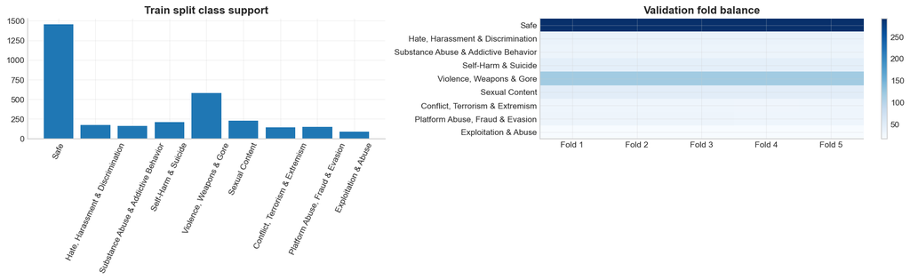

**Graph note**

These plots establish the data-balance context before any model comparison.

How to read it: The bar chart shows raw class support in train, so larger gaps indicate stronger imbalance pressure. The heatmap shows whether each validation fold preserves a roughly similar class mix; large deviations would make fold-to-fold comparisons less trustworthy.

This section is here to motivate why macro-F1 matters so much in the later beam-search stages.

|  | class_id | class_name | test_support | ensemble_test_f1 |
| --- | --- | --- | --- | --- |
| 0 | 0 | Safe | 312 | 0.908197 |
| 1 | 1 | Hate, Harassment & Discrimination | 38 | 0.613333 |
| 2 | 2 | Substance Abuse & Addictive Behavior | 34 | 0.720000 |
| 3 | 3 | Self-Harm & Suicide | 45 | 0.628571 |
| 4 | 4 | Violence, Weapons & Gore | 125 | 0.747826 |
| 5 | 5 | Sexual Content | 49 | 0.845361 |
| 6 | 6 | Conflict, Terrorism & Extremism | 31 | 0.684932 |
| 7 | 7 | Platform Abuse, Fraud & Evasion | 31 | 0.593750 |
| 8 | 8 | Exploitation & Abuse | 19 | 0.615385 |

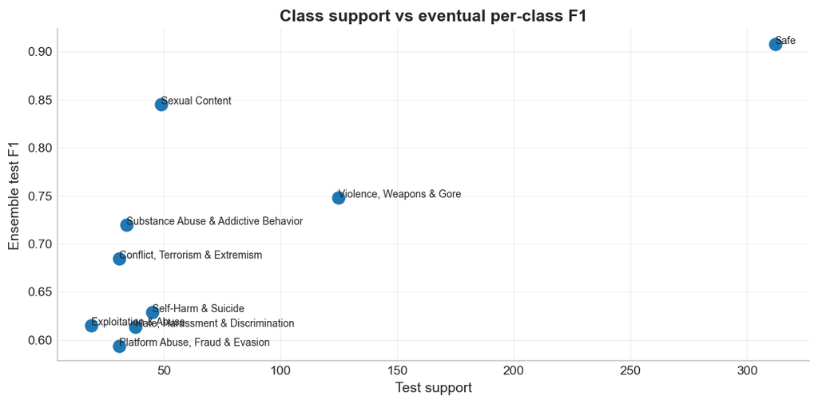

**Graph note**

This scatter links eventual per-class performance to class support on the held-out test set.

How to read it: Classes farther left have less support; classes lower on the plot have worse F1. A downward trend toward the low-support region suggests the model still struggles most on scarce subclasses.

This is descriptive rather than causal, but it helps explain why some unsafe subclasses remain harder even after tuning.

```
    **Finding.** The dataset is strongly imbalanced: `Safe` alone accounts for about 45.7% of the training split,
    while unsafe subclasses range from only 88 to 580 examples in train. Fold balance is reasonably controlled,
    but minority support is still far below the dominant classes. That is why **macro-F1 is the primary selection metric, and safety metrics are supporting evaluation lenses**:
    macro-F1 keeps minority subclasses visible in stage selection, while unsafe recall, unsafe-only macro-F1, and missed-as-safe rate help check whether a macro-F1 gain hides safety-critical regressions.
```

```python
split_counts_df = (
    pd.DataFrame(data_profile["split_counts"])
    .rename_axis("class_id")
    .reset_index()
    .assign(class_id=lambda df_: df_["class_id"].astype(int))
    .sort_values("class_id")
)
split_counts_df["class_name"] = split_counts_df["class_id"].map(dict(enumerate(class_labels)))
display(split_counts_df[["class_id", "class_name", "train", "val", "test"]])

fold_rows = []
for item in data_profile["fold_manifest"]:
    for class_id, count in item["val_counts"].items():
        fold_rows.append(
            {
                "fold_index": int(item["fold_index"]),
                "class_id": int(class_id),
                "class_name": class_labels[int(class_id)],
                "val_count": int(count),
            }
        )
fold_balance_df = pd.DataFrame(fold_rows).sort_values(["class_id", "fold_index"]).reset_index(drop=True)
fold_pivot = fold_balance_df.pivot(index="class_name", columns="fold_index", values="val_count").loc[class_labels]
display(fold_pivot)

fig, axes = plt.subplots(1, 2, figsize=(15.5, 4.8))
axes[0].bar(split_counts_df["class_name"], split_counts_df["train"])
axes[0].set_title("Train split class support")
axes[0].tick_params(axis="x", rotation=65)
im = axes[1].imshow(fold_pivot.to_numpy(), aspect="auto", cmap="Blues")
axes[1].set_title("Validation fold balance")
axes[1].set_xticks(np.arange(len(fold_pivot.columns)), labels=[f"Fold {c}" for c in fold_pivot.columns])
axes[1].set_yticks(np.arange(len(fold_pivot.index)), labels=fold_pivot.index)
fig.colorbar(im, ax=axes[1], fraction=0.046)
fig.tight_layout()
plt.show()
plt.close(fig)
display_note(
    title="Graph note",
    purpose="These plots establish the data-balance context before any model comparison.",
    how_to_read="The bar chart shows raw class support in train, so larger gaps indicate stronger imbalance pressure. The heatmap shows whether each validation fold preserves a roughly similar class mix; large deviations would make fold-to-fold comparisons less trustworthy.",
    caveat="This section is here to motivate why macro-F1 matters so much in the later beam-search stages."
)

ensemble_probs_test, ensemble_targets_test, finalist_prob_map_test, _ = full_ensemble_probs(split="test")
ensemble_test_metrics = metric_dict_from_probs(ensemble_probs_test, ensemble_targets_test)
support_context_df = pd.DataFrame(
    {
        "class_id": list(range(len(class_labels))),
        "class_name": class_labels,
        "test_support": ensemble_test_metrics["per_class_support"],
        "ensemble_test_f1": ensemble_test_metrics["per_class_f1"],
    }
)
display(support_context_df)

fig, ax = plt.subplots(figsize=(9, 4.5))
ax.scatter(support_context_df["test_support"], support_context_df["ensemble_test_f1"], s=90)
for _, row in support_context_df.iterrows():
    ax.annotate(row["class_name"], (row["test_support"], row["ensemble_test_f1"]), fontsize=8)
ax.set_xlabel("Test support")
ax.set_ylabel("Ensemble test F1")
ax.set_title("Class support vs eventual per-class F1")
fig.tight_layout()
plt.show()
plt.close(fig)
display_note(
    title="Graph note",
    purpose="This scatter links eventual per-class performance to class support on the held-out test set.",
    how_to_read="Classes farther left have less support; classes lower on the plot have worse F1. A downward trend toward the low-support region suggests the model still struggles most on scarce subclasses.",
    caveat="This is descriptive rather than causal, but it helps explain why some unsafe subclasses remain harder even after tuning."
)

safe_share = float(split_counts_df.loc[split_counts_df["class_id"] == 0, "train"].iloc[0] / split_counts_df["train"].sum())
smallest_unsafe = int(split_counts_df.loc[split_counts_df["class_id"] != 0, "train"].min())
largest_unsafe = int(split_counts_df.loc[split_counts_df["class_id"] != 0, "train"].max())
display(
    Markdown(
        f'''
        **Finding.** The dataset is strongly imbalanced: `Safe` alone accounts for about {safe_share:.1%} of the training split,
        while unsafe subclasses range from only {smallest_unsafe} to {largest_unsafe} examples in train. Fold balance is reasonably controlled,
        but minority support is still far below the dominant classes. That is why **macro-F1 is the primary selection metric, and safety metrics are supporting evaluation lenses**:
        macro-F1 keeps minority subclasses visible in stage selection, while unsafe recall, unsafe-only macro-F1, and missed-as-safe rate help check whether a macro-F1 gain hides safety-critical regressions.
        '''
    )
)
```

### What Each Stage Is Testing

Before reading the forensic audit, it helps to translate the stage names into plain language. This section builds directly on the glossary above: each stage below is a controlled recipe edit, not just a mysterious stage code. The beam search starts broad, then progressively narrows: early stages compare large design choices, while later stages mostly fine-tune or stress-test the surviving recipe family.

```python
def stage_scope_rows():
    rows = []
    for stage_name in stage_order:
        df = stage_df(stage_name)
        rows.append(
            {
                "stage": STAGE_TITLES[stage_name],
                "plain_language_goal": STAGE_PLAIN_LANGUAGE[stage_name],
                "specific_options_in_this_run": STAGE_OPTION_SUMMARY[stage_name],
                "candidates_considered": int(len(df)),
                "selected_to_next_stage": int(df["selected"].sum()) if "selected" in df.columns else np.nan,
            }
        )
    return pd.DataFrame(rows)

stage_scope_df = stage_scope_rows()
display(stage_scope_df[["stage", "plain_language_goal", "specific_options_in_this_run", "candidates_considered", "selected_to_next_stage"]])

display(
    Markdown(
        '''
        **Reading tip.** Early stages (`s1` to `s4`) test broad structural choices such as backbone family, output formulation, loss, and weighting.
        Middle stages (`s5` to `s8`) tune imbalance-handling and representation-capacity knobs inside the surviving family.
        Late stages (`s9` to `s11`) are narrower: they mainly recheck the late frontier, tune optimization, and then ask whether the shortlisted recipes still look good under more seeds.
        '''
    )
)

display(
    Markdown(
        '''
        **Finding.** The stage names are easier to read once translated into concrete modeling choices: this experiment starts with broad architecture and output-form comparisons,
        then shifts into imbalance handling, auxiliary-loss tuning, and finally robustness checks on a much narrower recipe family. That context matters when interpreting later stage margins:
        a Stage 2 gap answers a much bigger design question than a tiny Stage 10 optimizer separation.
        '''
    )
)
```

|  | stage | plain_language_goal | specific_options_in_this_run | candidates_considered | selected_to_next_stage |
| --- | --- | --- | --- | --- | --- |
| 0 | Stage 1: Architecture Warm Start | Choose the starting CLIP backbone, fusion mechanism, and classifier family. | Backbones/pretraining: ViT-B-16 with LAION B88 or DataComp B90, versus ViT-L-14 with LAION B82; fusion options: `concat`, `interaction`, `interaction_only`; head sizes: `linear`, `small`, `medium`. | 24 | 8 |
| 1 | Stage 2: Output Mode | Keep the base recipe similar, then change how the model predicts the 9 classes. | `flat`, `hierarchical`, and `flat_aux_hier`. | 24 | 10 |
| 2 | Stage 3: Loss Function | Hold the recipe mostly fixed and change the training loss. | `ce` versus focal loss with gamma 1.0 or 2.0. | 30 | 6 |
| 3 | Stage 4: Class Weighting | Change how class imbalance is weighted inside the loss. | `none`, `inverse`, and `effective` class weighting. | 18 | 7 |
| 4 | Stage 5: Sampler | Change how training batches are sampled. | `shuffle`, `balanced_binary`, and `balanced_flat9` samplers. | 21 | 7 |
| 5 | Stage 6: Effective-Number Beta | Tune how aggressive effective-number weighting should be. | `beta` in {0.99, 0.995, 0.999, 0.9995} when effective weighting survives. | 22 | 6 |
| 6 | Stage 7: Projection Dimension | Change the width of the interaction-style fused representation. | `proj_dim` in {256, 512, 768} for interaction-style fusion. | 18 | 6 |
| 7 | Stage 8: Auxiliary / Hierarchy Weighting | Tune how much hierarchy-aware auxiliary supervision is added. | `lambda_unsafe` for hierarchical runs; `aux_bin_w` and `aux_unsafe_w` for flat-aux-hier runs. | 18 | 6 |
| 8 | Stage 9: Backbone Recheck | Recheck whether the late-stage recipe should switch backbone family. | A tiny late-stage backbone/pretraining recheck across the surviving family only. | 2 | 2 |
| 9 | Stage 10: Optimizer Sweep | Tune optimizer settings on the narrowed late-stage frontier. | `lr` in {5e-4, 1e-3, 2e-3} and `weight_decay` in {1e-4, 5e-4}. | 8 | 6 |
| 10 | Stage 11: Robustness Rerun | Rerun the late finalists with more seeds to test robustness rather than invent a new family. | No new modeling knob; a broader seed budget on the late shortlist. | 6 | 4 |

```
    **Reading tip.** Early stages (`s1` to `s4`) test broad structural choices such as backbone family, output formulation, loss, and weighting.
    Middle stages (`s5` to `s8`) tune imbalance-handling and representation-capacity knobs inside the surviving family.
    Late stages (`s9` to `s11`) are narrower: they mainly recheck the late frontier, tune optimization, and then ask whether the shortlisted recipes still look good under more seeds.
```

```
    **Finding.** The stage names are easier to read once translated into concrete modeling choices: this experiment starts with broad architecture and output-form comparisons,
    then shifts into imbalance handling, auxiliary-loss tuning, and finally robustness checks on a much narrower recipe family. That context matters when interpreting later stage margins:
    a Stage 2 gap answers a much bigger design question than a tiny Stage 10 optimizer separation.
```

## Search Audit

This chapter explains how the beam search narrowed the design space. It starts with stage-by-stage evidence, then checks whether the observed margins are big enough to believe relative to fold/seed variation.

### Stage-By-Stage Forensic Audit

Each stage below shows the frontier as saved by the search artifacts, then drills down into matched candidates and representative run folders so the interpretation is anchored in raw run behavior rather than only aggregate tables.